# Capstone Project: Abison Chabalala

## Data Science nano degree 16-June-2024

# Customer Segmentation Report for a Financial Services

## Definition

### Project Overview

In this project, I will undertake a comprehensive analysis of customer demographics for a mail-order sales company based in Germany. This analysis will involve comparing customer demographics with those of the general population to gain insights into how the company's customer base aligns with broader societal trends. To achieve this, I will employ unsupervised learning techniques to segment the customer base into distinct groups, thereby identifying the specific demographic segments that most accurately represent the company's core customers.

### Problem Statement

The goal is to segment the custormers in different categories and use a model to predict which individuals are most likely to become custrmers for company

### Metrics

- accuracy
- ROC *

The data that I will use has been provided by our partners at Bertelsmann Arvato Analytics, and represents a real-life data science task.

The versions of those two datasets used in this project will include many more features and has not been pre-cleaned. You are also free to choose whatever approach you'd like to analyzing the data rather than follow pre-determined steps. In your work on this project, make sure that you carefully document your steps and decisions, since your main deliverable for this project will be a blog post reporting your findings.

```python
# import libraries here; add more as necessary

import pandas as pd
import numpy as np
import matplotlib.pyplot as plt
import seaborn as sns

# magic word for producing visualizations in notebook
%matplotlib inline
```

## Part 0: Get to Know the Data

Each row of the demographics files represents a single person, but also includes information outside of individuals, including information about their household, building, and neighborhood. Use the information from the first two files to figure out how customers ("CUSTOMERS") are similar to or differ from the general population at large ("AZDIAS"), then use your analysis to make predictions on the other two files ("MAILOUT"), predicting which recipients are most likely to become a customer for the mail-order company.

The "CUSTOMERS" file contains three extra columns ('CUSTOMER_GROUP', 'ONLINE_PURCHASE', and 'PRODUCT_GROUP'), which provide broad information about the customers depicted in the file. The original "MAILOUT" file included one additional column, "RESPONSE", which indicated whether or not each recipient became a customer of the company. For the "TRAIN" subset, this column has been retained, but in the "TEST" subset it has been removed; it is against that withheld column that your final predictions will be assessed in the Kaggle competition.

Otherwise, all of the remaining columns are the same between the three data files. For more information about the columns depicted in the files, you can refer to two Excel spreadsheets provided in the workspace. One of them is a top-level list of attributes and descriptions, organized by informational category. The other is a detailed mapping of data values for each feature in alphabetical order.

In the below cell, we've provided some initial code to load in the first two datasets. Note for all of the `.csv` data files in this project that they're semicolon (`;`) delimited, so an additional argument in the [`read_csv()`](https://pandas.pydata.org/pandas-docs/stable/generated/pandas.read_csv.html) call has been included to read in the data properly. Also, considering the size of the datasets, it may take some time for them to load completely.

You'll notice when the data is loaded in that a warning message will immediately pop up. Before you really start digging into the modeling and analysis, you're going to need to perform some cleaning. Take some time to browse the structure of the data and look over the informational spreadsheets to understand the data values. Make some decisions on which features to keep, which features to drop, and if any revisions need to be made on data formats. It'll be a good idea to create a function with pre-processing steps, since you'll need to clean all of the datasets before you work with them.

### Encountered errors when loading the dataset - Corrected

There was a warning about column 18 and 19 having multple data type, this is corrected by specifying the type to be all string. This is done by adding dtype parameter when reading the csv. column 18 and 19 are 'CAMEO_DEUG_2015' and'CAMEO_INTL_2015'respectively

```python
# load in the data
azdias = pd.read_csv('Udacity_AZDIAS.csv', sep=',',dtype={'CAMEO_DEUG_2015':str, 'CAMEO_INTL_2015': str})
customers = pd.read_csv('Udacity_CUSTOMERS.csv', sep=',', dtype={'CAMEO_DEUG_2015':str, 'CAMEO_INTL_2015': str})
```

```python
# check population data loaded
azdias.head()
```

|  | LNR | AGER_TYP | AKT_DAT_KL | ALTER_HH | ALTER_KIND1 | ALTER_KIND2 | ALTER_KIND3 | ALTER_KIND4 | ALTERSKATEGORIE_FEIN | ANZ_HAUSHALTE_AKTIV | ... | VHN | VK_DHT4A | VK_DISTANZ | VK_ZG11 | W_KEIT_KIND_HH | WOHNDAUER_2008 | WOHNLAGE | ZABEOTYP | ANREDE_KZ | ALTERSKATEGORIE_GROB |
| --- | --- | --- | --- | --- | --- | --- | --- | --- | --- | --- | --- | --- | --- | --- | --- | --- | --- | --- | --- | --- | --- |
| 0 | 910215 | -1 | NaN | NaN | NaN | NaN | NaN | NaN | NaN | NaN | ... | NaN | NaN | NaN | NaN | NaN | NaN | NaN | 3 | 1 | 2 |
| 1 | 910220 | -1 | 9.0 | 0.0 | NaN | NaN | NaN | NaN | 21.0 | 11.0 | ... | 4.0 | 8.0 | 11.0 | 10.0 | 3.0 | 9.0 | 4.0 | 5 | 2 | 1 |
| 2 | 910225 | -1 | 9.0 | 17.0 | NaN | NaN | NaN | NaN | 17.0 | 10.0 | ... | 2.0 | 9.0 | 9.0 | 6.0 | 3.0 | 9.0 | 2.0 | 5 | 2 | 3 |
| 3 | 910226 | 2 | 1.0 | 13.0 | NaN | NaN | NaN | NaN | 13.0 | 1.0 | ... | 0.0 | 7.0 | 10.0 | 11.0 | NaN | 9.0 | 7.0 | 3 | 2 | 4 |
| 4 | 910241 | -1 | 1.0 | 20.0 | NaN | NaN | NaN | NaN | 14.0 | 3.0 | ... | 2.0 | 3.0 | 5.0 | 4.0 | 2.0 | 9.0 | 3.0 | 4 | 1 | 3 |

5 rows × 366 columns

```python
# check customer data loaded
customers.head()
```

|  | LNR | AGER_TYP | AKT_DAT_KL | ALTER_HH | ALTER_KIND1 | ALTER_KIND2 | ALTER_KIND3 | ALTER_KIND4 | ALTERSKATEGORIE_FEIN | ANZ_HAUSHALTE_AKTIV | ... | VK_ZG11 | W_KEIT_KIND_HH | WOHNDAUER_2008 | WOHNLAGE | ZABEOTYP | PRODUCT_GROUP | CUSTOMER_GROUP | ONLINE_PURCHASE | ANREDE_KZ | ALTERSKATEGORIE_GROB |
| --- | --- | --- | --- | --- | --- | --- | --- | --- | --- | --- | --- | --- | --- | --- | --- | --- | --- | --- | --- | --- | --- |
| 0 | 9626 | 2 | 1.0 | 10.0 | NaN | NaN | NaN | NaN | 10.0 | 1.0 | ... | 2.0 | 6.0 | 9.0 | 7.0 | 3 | COSMETIC_AND_FOOD | MULTI_BUYER | 0 | 1 | 4 |
| 1 | 9628 | -1 | 9.0 | 11.0 | NaN | NaN | NaN | NaN | NaN | NaN | ... | 3.0 | 0.0 | 9.0 | NaN | 3 | FOOD | SINGLE_BUYER | 0 | 1 | 4 |
| 2 | 143872 | -1 | 1.0 | 6.0 | NaN | NaN | NaN | NaN | 0.0 | 1.0 | ... | 11.0 | 6.0 | 9.0 | 2.0 | 3 | COSMETIC_AND_FOOD | MULTI_BUYER | 0 | 2 | 4 |
| 3 | 143873 | 1 | 1.0 | 8.0 | NaN | NaN | NaN | NaN | 8.0 | 0.0 | ... | 2.0 | NaN | 9.0 | 7.0 | 1 | COSMETIC | MULTI_BUYER | 0 | 1 | 4 |
| 4 | 143874 | -1 | 1.0 | 20.0 | NaN | NaN | NaN | NaN | 14.0 | 7.0 | ... | 4.0 | 2.0 | 9.0 | 3.0 | 1 | FOOD | MULTI_BUYER | 0 | 1 | 3 |

5 rows × 369 columns

```python
# check shape of loaded datasets
print("Shape of population dataset",azdias.shape)
print("Shape of customers dataset",customers.shape)
```

```
Shape of population dataset (891221, 366)
Shape of customers dataset (191652, 369)
```

## Data Cleaning

```python
#check for columns that have null(NaN)
# calculating the percentage of NaN on azdias dataframe and display columns that are above 30%
AA =(azdias.isna().sum()/891221)*100
AA[AA>30].sort_values(ascending =False)
```

```
ALTER_KIND4     99.864792
ALTER_KIND3     99.307691
ALTER_KIND2     96.690047
ALTER_KIND1     90.904837
EXTSEL992       73.399639
KK_KUNDENTYP    65.596749
dtype: float64
```

```python
# calculating the percentage of NaN on custormers dataframe and display columns that are above 30%
BB =(customers.isna().sum()/191652)*100
BB[BB>30].sort_values(ascending =False)
```

```
ALTER_KIND4     99.876860
ALTER_KIND3     99.334732
ALTER_KIND2     97.338927
ALTER_KIND1     93.860748
KK_KUNDENTYP    58.406382
EXTSEL992       44.498883
dtype: float64
```

### Observation:

- From above it can be seen that the population data(azdias) and custormer data(custormers) have six common columns with the most missing values, hence it is advisable that they be dropped.
- The common columns are ['ALTER_KIND4', 'ALTER_KIND3', 'ALTER_KIND2', 'ALTER_KIND1','KK_KUNDENTYP', 'EXTSEL992']

```python
# drop colums with high NaN in azdias and custormers dataframe
azdias= azdias.drop(['ALTER_KIND4', 'ALTER_KIND3', 'ALTER_KIND2', 'ALTER_KIND1','KK_KUNDENTYP', 'EXTSEL992'], axis=1)
customers = customers.drop(['ALTER_KIND4', 'ALTER_KIND3', 'ALTER_KIND2', 'ALTER_KIND1','KK_KUNDENTYP', 'EXTSEL992'], axis=1)
```

### Observation:

- most of unknown attributes are flagged with -1, it make sense to fill the rest of NaN with -1 rather than dropping the entire row/column.

```python
# filling the NaN with -1
azdias.fillna(value=-1, inplace = True)
```

```python
# filling the NaN with -1
customers.fillna(value=-1, inplace = True)
```

```python
# save the clean dataframef in new dataframe
customer_clean_df = customers
population_data_df =azdias
```

```python
# based on above a cleaning function can be created
#create a function to clean dataframe

def clean_dataframe(df):

    """
    This function takes a DataFrame as input, drops specified columns with high proportions of NaN values,
    and replaces any remaining NaN values with -1.

    Parameters:
    df : pandas.DataFrame
        The input DataFrame to be cleaned.

    Returns:
    pandas.DataFrame
        The cleaned DataFrame.
    """
   # Drop specific columns that are not needed
    columns_to_drop = ['ALTER_KIND4', 'ALTER_KIND3', 'ALTER_KIND2', 'ALTER_KIND1', 'KK_KUNDENTYP', 'EXTSEL992']
    df = df.drop(columns=columns_to_drop, axis=1, errors='ignore')

    # filling the NaN with -1
    df.fillna(value=-1, inplace = True)

    #removing columns with string
    df.drop(['CAMEO_DEU_2015',
                         'CAMEO_DEUG_2015',
                         'CAMEO_INTL_2015',
                         'D19_LETZTER_KAUF_BRANCHE',
                         'EINGEFUEGT_AM',
                         'OST_WEST_KZ'], axis=1, inplace=True)


    return df
```

## Explorataty Data Analysis(EDA) and Visualization

```python
# Person attributes
```

```python
customer_clean_df.head()
```

|  | LNR | AGER_TYP | AKT_DAT_KL | ALTER_HH | ALTERSKATEGORIE_FEIN | ANZ_HAUSHALTE_AKTIV | ANZ_HH_TITEL | ANZ_KINDER | ANZ_PERSONEN | ANZ_STATISTISCHE_HAUSHALTE | ... | VK_ZG11 | W_KEIT_KIND_HH | WOHNDAUER_2008 | WOHNLAGE | ZABEOTYP | PRODUCT_GROUP | CUSTOMER_GROUP | ONLINE_PURCHASE | ANREDE_KZ | ALTERSKATEGORIE_GROB |
| --- | --- | --- | --- | --- | --- | --- | --- | --- | --- | --- | --- | --- | --- | --- | --- | --- | --- | --- | --- | --- | --- |
| 0 | 9626 | 2 | 1.0 | 10.0 | 10.0 | 1.0 | 0.0 | 0.0 | 2.0 | 1.0 | ... | 2.0 | 6.0 | 9.0 | 7.0 | 3 | COSMETIC_AND_FOOD | MULTI_BUYER | 0 | 1 | 4 |
| 1 | 9628 | -1 | 9.0 | 11.0 | -1.0 | -1.0 | -1.0 | 0.0 | 3.0 | -1.0 | ... | 3.0 | 0.0 | 9.0 | -1.0 | 3 | FOOD | SINGLE_BUYER | 0 | 1 | 4 |
| 2 | 143872 | -1 | 1.0 | 6.0 | 0.0 | 1.0 | 0.0 | 0.0 | 1.0 | 1.0 | ... | 11.0 | 6.0 | 9.0 | 2.0 | 3 | COSMETIC_AND_FOOD | MULTI_BUYER | 0 | 2 | 4 |
| 3 | 143873 | 1 | 1.0 | 8.0 | 8.0 | 0.0 | -1.0 | 0.0 | 0.0 | 1.0 | ... | 2.0 | -1.0 | 9.0 | 7.0 | 1 | COSMETIC | MULTI_BUYER | 0 | 1 | 4 |
| 4 | 143874 | -1 | 1.0 | 20.0 | 14.0 | 7.0 | 0.0 | 0.0 | 4.0 | 7.0 | ... | 4.0 | 2.0 | 9.0 | 3.0 | 1 | FOOD | MULTI_BUYER | 0 | 1 | 3 |

5 rows × 363 columns

```python
#show descriptive statistics for customer data
customer_clean_df.describe()
```

|  | LNR | AGER_TYP | AKT_DAT_KL | ALTER_HH | ALTERSKATEGORIE_FEIN | ANZ_HAUSHALTE_AKTIV | ANZ_HH_TITEL | ANZ_KINDER | ANZ_PERSONEN | ANZ_STATISTISCHE_HAUSHALTE | ... | VK_DHT4A | VK_DISTANZ | VK_ZG11 | W_KEIT_KIND_HH | WOHNDAUER_2008 | WOHNLAGE | ZABEOTYP | ONLINE_PURCHASE | ANREDE_KZ | ALTERSKATEGORIE_GROB |
| --- | --- | --- | --- | --- | --- | --- | --- | --- | --- | --- | --- | --- | --- | --- | --- | --- | --- | --- | --- | --- | --- |
| count | 191652.000000 | 191652.000000 | 191652.000000 | 191652.000000 | 191652.000000 | 191652.000000 | 191652.000000 | 191652.000000 | 191652.000000 | 191652.000000 | ... | 191652.000000 | 191652.000000 | 191652.000000 | 191652.000000 | 191652.000000 | 191652.000000 | 191652.000000 | 191652.000000 | 191652.000000 | 191652.000000 |
| mean | 95826.500000 | 0.344359 | 1.079524 | 8.348888 | 7.266379 | 3.411705 | -0.222815 | -0.139889 | 1.473327 | 3.216053 | ... | 3.031990 | 3.174796 | 2.127565 | 2.707819 | 6.301067 | 2.492716 | 2.576806 | 0.090247 | 1.376432 | 3.060907 |
| std | 55325.311233 | 1.391672 | 2.077390 | 7.607791 | 6.149009 | 12.580935 | 0.665044 | 0.649450 | 1.851682 | 12.451445 | ... | 3.439249 | 3.472165 | 2.645617 | 2.857008 | 4.258081 | 2.746786 | 1.168486 | 0.286536 | 0.484492 | 1.086254 |
| min | 1.000000 | -1.000000 | -1.000000 | -1.000000 | -1.000000 | -1.000000 | -1.000000 | -1.000000 | -1.000000 | -1.000000 | ... | -1.000000 | -1.000000 | -1.000000 | -1.000000 | -1.000000 | -1.000000 | 1.000000 | 0.000000 | 1.000000 | 1.000000 |
| 25% | 47913.750000 | -1.000000 | 1.000000 | 0.000000 | -1.000000 | -1.000000 | -1.000000 | 0.000000 | 0.000000 | -1.000000 | ... | 1.000000 | 1.000000 | 1.000000 | -1.000000 | 3.000000 | -1.000000 | 1.000000 | 0.000000 | 1.000000 | 3.000000 |
| 50% | 95826.500000 | 0.000000 | 1.000000 | 9.000000 | 9.000000 | 1.000000 | 0.000000 | 0.000000 | 2.000000 | 1.000000 | ... | 2.000000 | 3.000000 | 2.000000 | 3.000000 | 9.000000 | 3.000000 | 3.000000 | 0.000000 | 1.000000 | 3.000000 |
| 75% | 143739.250000 | 2.000000 | 1.000000 | 15.000000 | 12.000000 | 2.000000 | 0.000000 | 0.000000 | 3.000000 | 2.000000 | ... | 6.000000 | 6.000000 | 4.000000 | 6.000000 | 9.000000 | 4.000000 | 3.000000 | 0.000000 | 2.000000 | 4.000000 |
| max | 191652.000000 | 3.000000 | 9.000000 | 21.000000 | 25.000000 | 523.000000 | 23.000000 | 8.000000 | 21.000000 | 375.000000 | ... | 11.000000 | 13.000000 | 11.000000 | 6.000000 | 9.000000 | 8.000000 | 6.000000 | 1.000000 | 2.000000 | 9.000000 |

8 rows × 355 columns

```python
population_data_df.head()
```

|  | LNR | AGER_TYP | AKT_DAT_KL | ALTER_HH | ALTERSKATEGORIE_FEIN | ANZ_HAUSHALTE_AKTIV | ANZ_HH_TITEL | ANZ_KINDER | ANZ_PERSONEN | ANZ_STATISTISCHE_HAUSHALTE | ... | VHN | VK_DHT4A | VK_DISTANZ | VK_ZG11 | W_KEIT_KIND_HH | WOHNDAUER_2008 | WOHNLAGE | ZABEOTYP | ANREDE_KZ | ALTERSKATEGORIE_GROB |
| --- | --- | --- | --- | --- | --- | --- | --- | --- | --- | --- | --- | --- | --- | --- | --- | --- | --- | --- | --- | --- | --- |
| 0 | 910215 | -1 | -1.0 | -1.0 | -1.0 | -1.0 | -1.0 | -1.0 | -1.0 | -1.0 | ... | -1.0 | -1.0 | -1.0 | -1.0 | -1.0 | -1.0 | -1.0 | 3 | 1 | 2 |
| 1 | 910220 | -1 | 9.0 | 0.0 | 21.0 | 11.0 | 0.0 | 0.0 | 2.0 | 12.0 | ... | 4.0 | 8.0 | 11.0 | 10.0 | 3.0 | 9.0 | 4.0 | 5 | 2 | 1 |
| 2 | 910225 | -1 | 9.0 | 17.0 | 17.0 | 10.0 | 0.0 | 0.0 | 1.0 | 7.0 | ... | 2.0 | 9.0 | 9.0 | 6.0 | 3.0 | 9.0 | 2.0 | 5 | 2 | 3 |
| 3 | 910226 | 2 | 1.0 | 13.0 | 13.0 | 1.0 | 0.0 | 0.0 | 0.0 | 2.0 | ... | 0.0 | 7.0 | 10.0 | 11.0 | -1.0 | 9.0 | 7.0 | 3 | 2 | 4 |
| 4 | 910241 | -1 | 1.0 | 20.0 | 14.0 | 3.0 | 0.0 | 0.0 | 4.0 | 3.0 | ... | 2.0 | 3.0 | 5.0 | 4.0 | 2.0 | 9.0 | 3.0 | 4 | 1 | 3 |

5 rows × 360 columns

```python
#show descriptive statistics for population data
population_data_df.describe()
```

|  | LNR | AGER_TYP | AKT_DAT_KL | ALTER_HH | ALTERSKATEGORIE_FEIN | ANZ_HAUSHALTE_AKTIV | ANZ_HH_TITEL | ANZ_KINDER | ANZ_PERSONEN | ANZ_STATISTISCHE_HAUSHALTE | ... | VHN | VK_DHT4A | VK_DISTANZ | VK_ZG11 | W_KEIT_KIND_HH | WOHNDAUER_2008 | WOHNLAGE | ZABEOTYP | ANREDE_KZ | ALTERSKATEGORIE_GROB |
| --- | --- | --- | --- | --- | --- | --- | --- | --- | --- | --- | --- | --- | --- | --- | --- | --- | --- | --- | --- | --- | --- |
| count | 8.912210e+05 | 891221.000000 | 891221.000000 | 891221.000000 | 891221.000000 | 891221.000000 | 891221.000000 | 891221.000000 | 891221.000000 | 891221.000000 | ... | 891221.000000 | 891221.000000 | 891221.000000 | 891221.000000 | 891221.000000 | 891221.000000 | 891221.000000 | 891221.000000 | 891221.000000 | 891221.000000 |
| mean | 6.372630e+05 | -0.358435 | 3.974782 | 9.885692 | 9.363398 | 7.316584 | -0.072626 | 0.058846 | 1.502689 | 6.700575 | ... | 1.952604 | 5.404829 | 6.805337 | 5.354293 | 3.337769 | 7.174083 | 3.524727 | 3.362438 | 1.522098 | 2.777398 |
| std | 2.572735e+05 | 1.198724 | 3.791224 | 8.012638 | 7.946117 | 15.059310 | 0.445659 | 0.576500 | 1.337455 | 13.815354 | ... | 1.596231 | 3.358891 | 3.914394 | 3.284270 | 2.444943 | 3.065781 | 2.406868 | 1.352704 | 0.499512 | 1.068775 |
| min | 1.916530e+05 | -1.000000 | -1.000000 | -1.000000 | -1.000000 | -1.000000 | -1.000000 | -1.000000 | -1.000000 | -1.000000 | ... | -1.000000 | -1.000000 | -1.000000 | -1.000000 | -1.000000 | -1.000000 | -1.000000 | 1.000000 | 1.000000 | 1.000000 |
| 25% | 4.144580e+05 | -1.000000 | 1.000000 | 0.000000 | -1.000000 | 1.000000 | 0.000000 | 0.000000 | 1.000000 | 1.000000 | ... | 1.000000 | 3.000000 | 4.000000 | 3.000000 | 1.000000 | 6.000000 | 2.000000 | 3.000000 | 1.000000 | 2.000000 |
| 50% | 6.372630e+05 | -1.000000 | 1.000000 | 12.000000 | 12.000000 | 3.000000 | 0.000000 | 0.000000 | 1.000000 | 3.000000 | ... | 2.000000 | 6.000000 | 7.000000 | 6.000000 | 4.000000 | 9.000000 | 3.000000 | 3.000000 | 2.000000 | 3.000000 |
| 75% | 8.600680e+05 | -1.000000 | 9.000000 | 17.000000 | 16.000000 | 9.000000 | 0.000000 | 0.000000 | 2.000000 | 8.000000 | ... | 3.000000 | 8.000000 | 10.000000 | 8.000000 | 6.000000 | 9.000000 | 5.000000 | 4.000000 | 2.000000 | 4.000000 |
| max | 1.082873e+06 | 3.000000 | 9.000000 | 21.000000 | 25.000000 | 595.000000 | 23.000000 | 11.000000 | 45.000000 | 449.000000 | ... | 4.000000 | 11.000000 | 13.000000 | 11.000000 | 6.000000 | 9.000000 | 8.000000 | 6.000000 | 2.000000 | 9.000000 |

8 rows × 354 columns

```python
# check propotion of men and women in azdias dataset

gender_=population_data_df['ANREDE_KZ'].value_counts()
```

```python
gender_
```

```
2    465305
1    425916
Name: ANREDE_KZ, dtype: int64
```

```python
# check propotion of men and women in custormer dataset
gender_c=customer_clean_df['ANREDE_KZ'].value_counts()
```

```python
gender_c
```

```
1    119508
2     72144
Name: ANREDE_KZ, dtype: int64
```

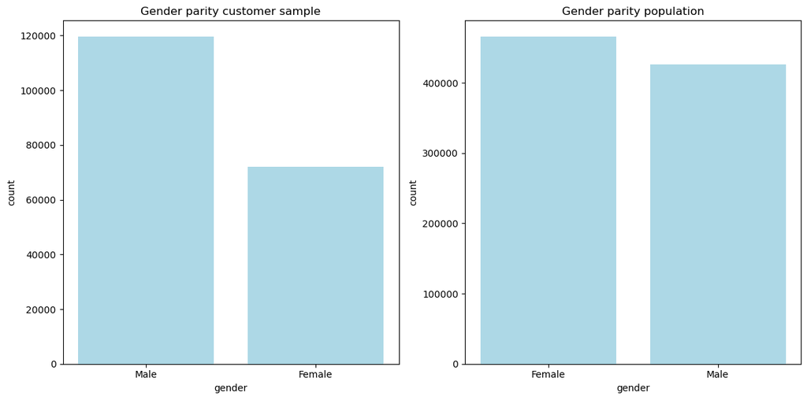

```python
# Create a figure and axes (subplots)
fig, (ax1, ax2) = plt.subplots(1, 2, figsize=(12, 6))  # 1 row, 2 columns

# Plotting Series 1 on ax1
ax1.bar(['Male','Female'], gender_c, color='lightblue')
ax1.set_title('Gender parity customer sample')
ax1.set_xlabel('gender')
ax1.set_ylabel('count')
#ax1.grid(True)

# Plotting Series 2 on ax2
ax2.bar(['Female','Male'], gender_, color='lightblue')
ax2.set_title('Gender parity population')
ax2.set_xlabel('gender')
ax2.set_ylabel('count')
#ax2.grid(True)

# Adjust layout to prevent overlap of labels
plt.tight_layout()

# Show plot
plt.show()
```

- on the sampled custormer data there is an imbalance between men and womwn(62/38) split while on population the women are marginaly higher at 52%.

```python
# based on above, create a function to do more of this plots
def plot_compare(population_data_df, customer_clean_df, column_name):
    """
    Create a figure with two subplots to display the count distribution of a specified column from two datasets.

    Parameters:
    - population_data_df (DataFrame): DataFrame containing population data.
    - customer_clean_df (DataFrame): DataFrame containing customer data.
    - column_name (str): The name of the column to compare between the datasets.
    """
    # Get value counts from each dataset for the specified column
    population_counts = population_data_df[column_name].value_counts()
    customer_counts = customer_clean_df[column_name].value_counts()

    # Create a figure and axes (subplots)
    fig, (ax1, ax2) = plt.subplots(1, 2, figsize=(12, 6))  # 1 row, 2 columns

    # Plotting Series 1 on ax1
    ax1.bar(customer_counts.index, customer_counts.values, color='green')
    ax1.set_title('Customer Sample')
    ax1.set_xlabel(column_name)
    ax1.set_ylabel('Count')
    ax1.set_xticks(customer_counts.index)  # Ensure x-ticks match the bars
    ax1.set_xticklabels(customer_counts.index, rotation=45)  # Rotate labels if necessary

    # Plotting Series 2 on ax2
    ax2.bar(population_counts.index, population_counts.values, color='lightblue')
    ax2.set_title('Population')
    ax2.set_xlabel(column_name)
    ax2.set_ylabel('Count')
    ax2.set_xticks(population_counts.index)  # Ensure x-ticks match the bars
    ax2.set_xticklabels(population_counts.index, rotation=45)  # Rotate labels if necessary

    # Adjust layout to prevent overlap of labels
    plt.tight_layout()

    # Show plot
    plt.show()
```

```python
# Value to drop
value_to_drop = 'X'

# Drop rows where column 'CAMEO_DEUG_2015' has the value 'X'
customer_clean_df = customer_clean_df[customer_clean_df['CAMEO_DEUG_2015'] != value_to_drop]
population_data_df = population_data_df[population_data_df['CAMEO_DEUG_2015'] != value_to_drop]
```

```python
population_data_df.head()
```

|  | LNR | AGER_TYP | AKT_DAT_KL | ALTER_HH | ALTERSKATEGORIE_FEIN | ANZ_HAUSHALTE_AKTIV | ANZ_HH_TITEL | ANZ_KINDER | ANZ_PERSONEN | ANZ_STATISTISCHE_HAUSHALTE | ... | VHN | VK_DHT4A | VK_DISTANZ | VK_ZG11 | W_KEIT_KIND_HH | WOHNDAUER_2008 | WOHNLAGE | ZABEOTYP | ANREDE_KZ | ALTERSKATEGORIE_GROB |
| --- | --- | --- | --- | --- | --- | --- | --- | --- | --- | --- | --- | --- | --- | --- | --- | --- | --- | --- | --- | --- | --- |
| 0 | 910215 | -1 | -1.0 | -1.0 | -1.0 | -1.0 | -1.0 | -1.0 | -1.0 | -1.0 | ... | -1.0 | -1.0 | -1.0 | -1.0 | -1.0 | -1.0 | -1.0 | 3 | 1 | 2 |
| 1 | 910220 | -1 | 9.0 | 0.0 | 21.0 | 11.0 | 0.0 | 0.0 | 2.0 | 12.0 | ... | 4.0 | 8.0 | 11.0 | 10.0 | 3.0 | 9.0 | 4.0 | 5 | 2 | 1 |
| 2 | 910225 | -1 | 9.0 | 17.0 | 17.0 | 10.0 | 0.0 | 0.0 | 1.0 | 7.0 | ... | 2.0 | 9.0 | 9.0 | 6.0 | 3.0 | 9.0 | 2.0 | 5 | 2 | 3 |
| 3 | 910226 | 2 | 1.0 | 13.0 | 13.0 | 1.0 | 0.0 | 0.0 | 0.0 | 2.0 | ... | 0.0 | 7.0 | 10.0 | 11.0 | -1.0 | 9.0 | 7.0 | 3 | 2 | 4 |
| 4 | 910241 | -1 | 1.0 | 20.0 | 14.0 | 3.0 | 0.0 | 0.0 | 4.0 | 3.0 | ... | 2.0 | 3.0 | 5.0 | 4.0 | 2.0 | 9.0 | 3.0 | 4 | 1 | 3 |

5 rows × 360 columns

```python
customer_clean_df.head()
```

|  | LNR | AGER_TYP | AKT_DAT_KL | ALTER_HH | ALTERSKATEGORIE_FEIN | ANZ_HAUSHALTE_AKTIV | ANZ_HH_TITEL | ANZ_KINDER | ANZ_PERSONEN | ANZ_STATISTISCHE_HAUSHALTE | ... | VK_ZG11 | W_KEIT_KIND_HH | WOHNDAUER_2008 | WOHNLAGE | ZABEOTYP | PRODUCT_GROUP | CUSTOMER_GROUP | ONLINE_PURCHASE | ANREDE_KZ | ALTERSKATEGORIE_GROB |
| --- | --- | --- | --- | --- | --- | --- | --- | --- | --- | --- | --- | --- | --- | --- | --- | --- | --- | --- | --- | --- | --- |
| 0 | 9626 | 2 | 1.0 | 10.0 | 10.0 | 1.0 | 0.0 | 0.0 | 2.0 | 1.0 | ... | 2.0 | 6.0 | 9.0 | 7.0 | 3 | COSMETIC_AND_FOOD | MULTI_BUYER | 0 | 1 | 4 |
| 1 | 9628 | -1 | 9.0 | 11.0 | -1.0 | -1.0 | -1.0 | 0.0 | 3.0 | -1.0 | ... | 3.0 | 0.0 | 9.0 | -1.0 | 3 | FOOD | SINGLE_BUYER | 0 | 1 | 4 |
| 2 | 143872 | -1 | 1.0 | 6.0 | 0.0 | 1.0 | 0.0 | 0.0 | 1.0 | 1.0 | ... | 11.0 | 6.0 | 9.0 | 2.0 | 3 | COSMETIC_AND_FOOD | MULTI_BUYER | 0 | 2 | 4 |
| 3 | 143873 | 1 | 1.0 | 8.0 | 8.0 | 0.0 | -1.0 | 0.0 | 0.0 | 1.0 | ... | 2.0 | -1.0 | 9.0 | 7.0 | 1 | COSMETIC | MULTI_BUYER | 0 | 1 | 4 |
| 4 | 143874 | -1 | 1.0 | 20.0 | 14.0 | 7.0 | 0.0 | 0.0 | 4.0 | 7.0 | ... | 4.0 | 2.0 | 9.0 | 3.0 | 1 | FOOD | MULTI_BUYER | 0 | 1 | 3 |

5 rows × 363 columns

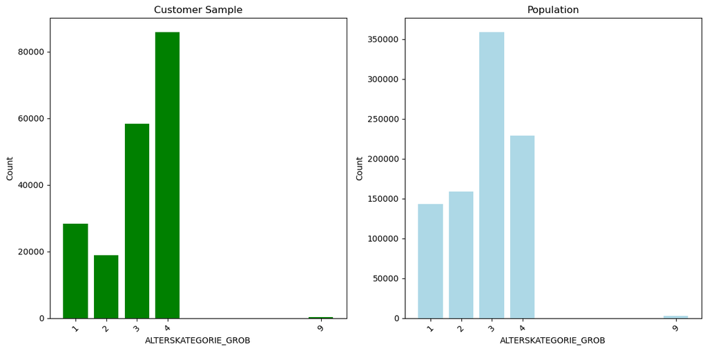

```python
# Plot age classification through prename analysis
plot_compare(population_data_df,customer_clean_df,'ALTERSKATEGORIE_GROB')
```

- on sample custormer data, there is more elder people than population in general.

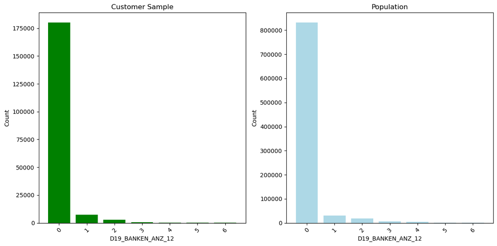

```python
# Plot propotion of shopping topology
plot_compare(population_data_df,customer_clean_df,'D19_BANKEN_ANZ_12')
```

- A lot of transaction is unknown(0)

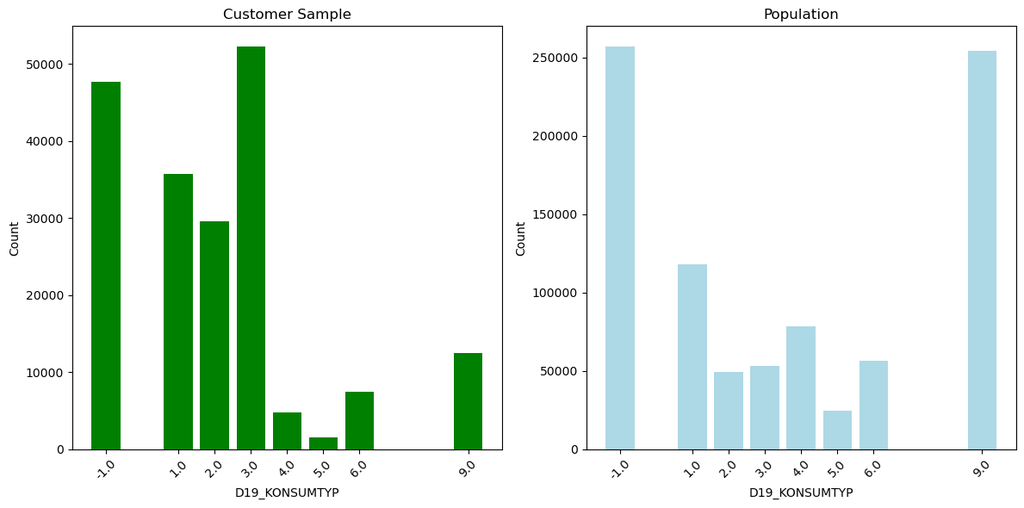

```python
# Plot consumption type
plot_compare(population_data_df,customer_clean_df,'D19_KONSUMTYP')
```

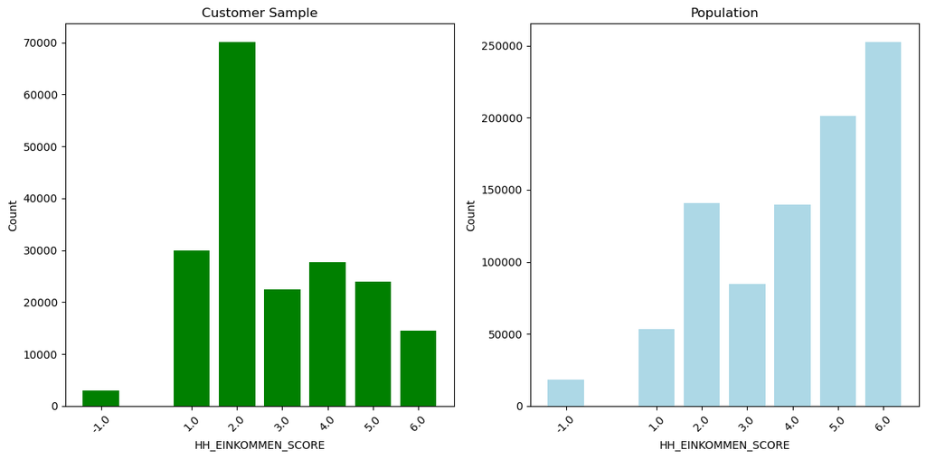

```python
# Plot income type
plot_compare(population_data_df,customer_clean_df,'HH_EINKOMMEN_SCORE')
```

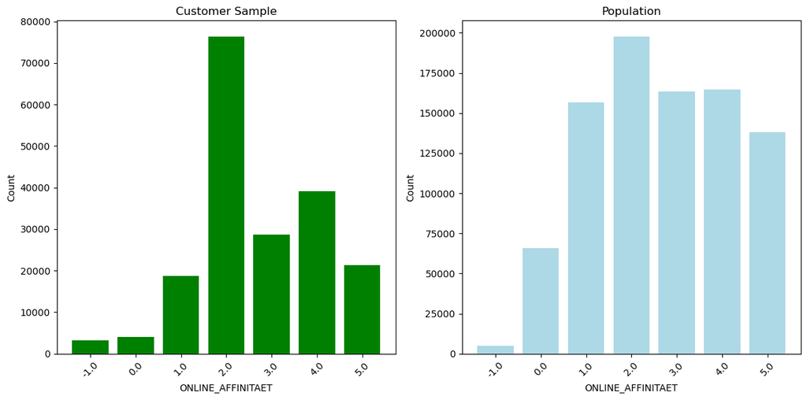

```python
# Plot online affinity type
plot_compare(population_data_df,customer_clean_df,'ONLINE_AFFINITAET')
```

- balanced. Middle(2) online affinity

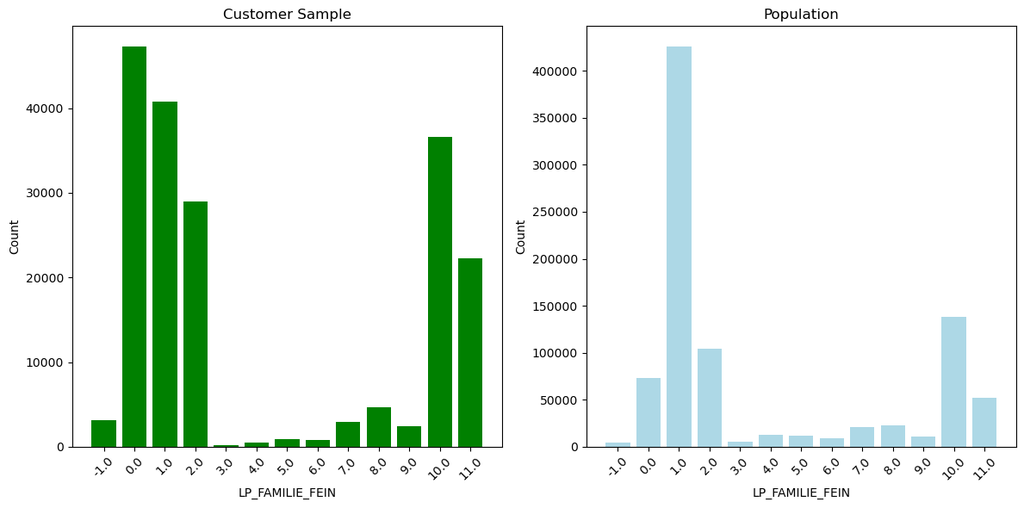

```python
# Plot Family status
plot_compare(population_data_df,customer_clean_df,'LP_FAMILIE_FEIN')
```

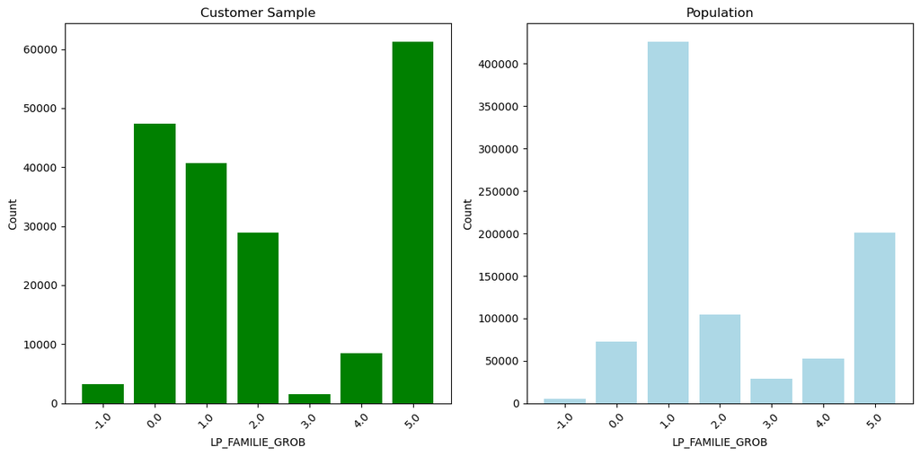

```python
# Plot Family status
plot_compare(population_data_df,customer_clean_df,'LP_FAMILIE_GROB')
```

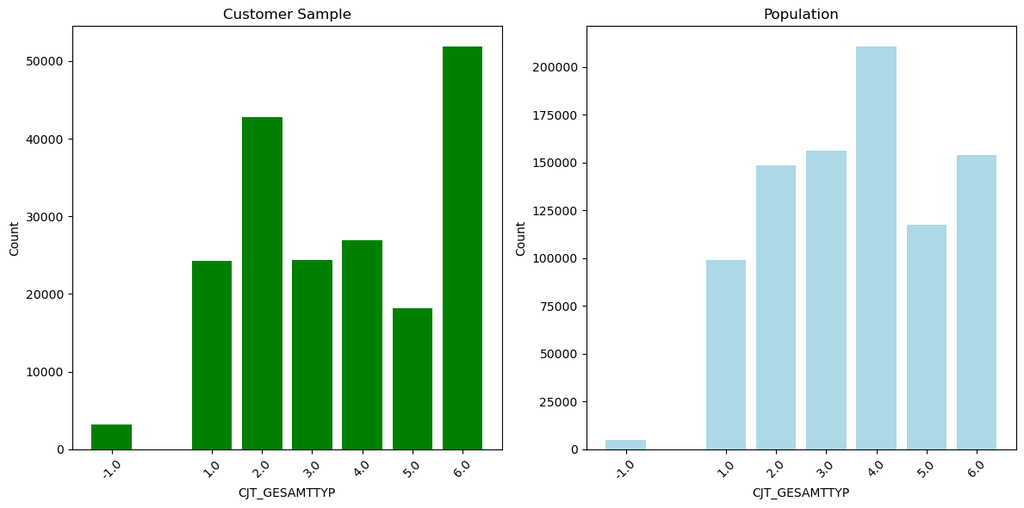

```python
# Plot customer journey typology
plot_compare(population_data_df,customer_clean_df,'CJT_GESAMTTYP')
```

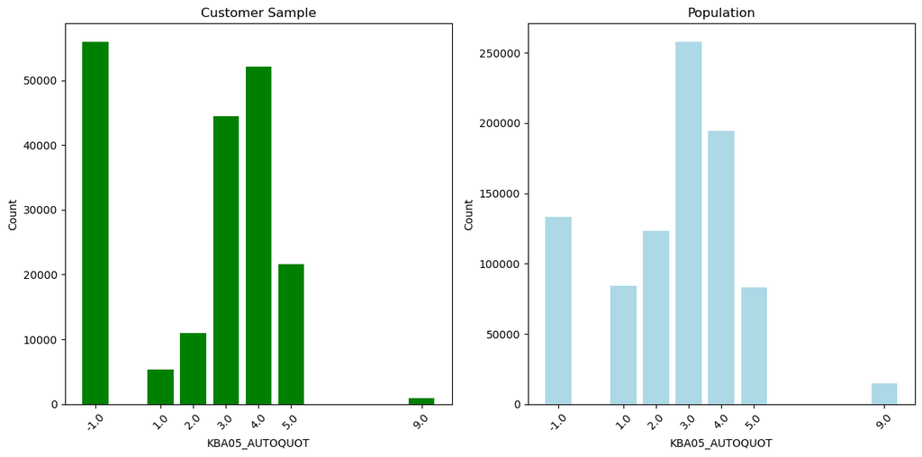

```python
# Plot carr sharing in household
plot_compare(population_data_df,customer_clean_df,'KBA05_AUTOQUOT')
```

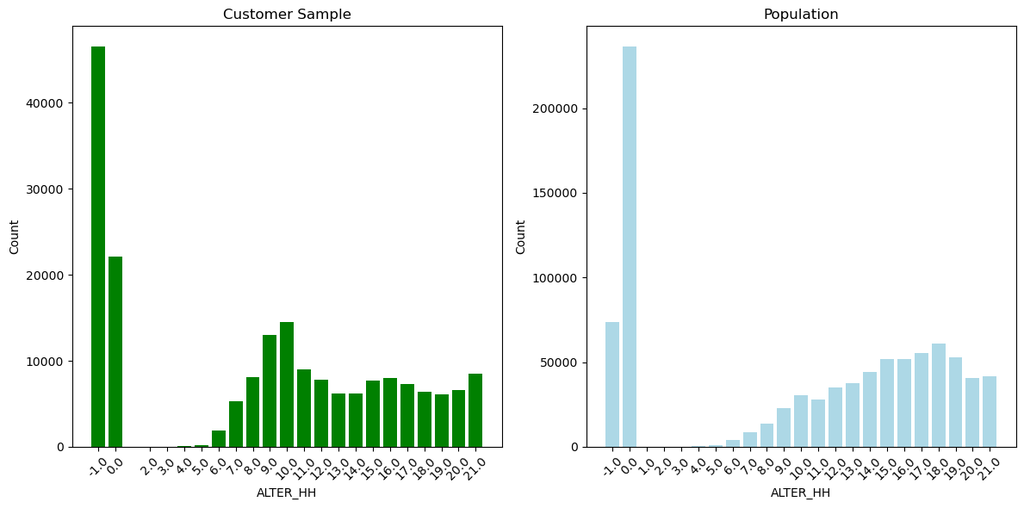

```python
# Plot main age in household
plot_compare(population_data_df,customer_clean_df,'ALTER_HH')
```

## DATA TYPES - checking

```python
custormer_clean_df.dtypes
```

```
LNR                       int64
AGER_TYP                  int64
AKT_DAT_KL              float64
ALTER_HH                float64
ALTERSKATEGORIE_FEIN    float64
                         ...
PRODUCT_GROUP            object
CUSTOMER_GROUP           object
ONLINE_PURCHASE           int64
ANREDE_KZ                 int64
ALTERSKATEGORIE_GROB      int64
Length: 363, dtype: object
```

```python
# Loop through each column and print column name if not int or float
for column in custormer_clean_df.columns:
    data_type = custormer_clean_df[column].dtype
    if data_type not in ['int64', 'float64']:
        print(f'Column {column} has data type {data_type}')
```

```
Column CAMEO_DEU_2015 has data type object
Column CAMEO_DEUG_2015 has data type object
Column CAMEO_INTL_2015 has data type object
Column D19_LETZTER_KAUF_BRANCHE has data type object
Column EINGEFUEGT_AM has data type object
Column OST_WEST_KZ has data type object
Column PRODUCT_GROUP has data type object
Column CUSTOMER_GROUP has data type object
```

```python
# Loop through each column and print column name if not int or float
for column in population_data_df.columns:
    data_type = population_data_df[column].dtype
    if data_type not in ['int64', 'float64']:
        print(f'Column {column} has data type {data_type}')
```

```
Column CAMEO_DEU_2015 has data type object
Column CAMEO_DEUG_2015 has data type object
Column CAMEO_INTL_2015 has data type object
Column D19_LETZTER_KAUF_BRANCHE has data type object
Column EINGEFUEGT_AM has data type object
Column OST_WEST_KZ has data type object
```

```python
custormer_clean_df.shape
```

```
(191526, 363)
```

```python
population_data_df.shape
```

```
(890848, 360)
```

## DROPPING MORE COLUMNS

```python
#removing columns with string
custormer_clean_df.drop(['CAMEO_DEU_2015',
                         'CAMEO_DEUG_2015',
                         'CAMEO_INTL_2015',
                         'D19_LETZTER_KAUF_BRANCHE',
                         'EINGEFUEGT_AM',
                         'OST_WEST_KZ'], axis=1, inplace=True)
```

```python
#removing columns with string
population_data_df.drop(['CAMEO_DEU_2015',
                         'CAMEO_DEUG_2015',
                         'CAMEO_INTL_2015',
                         'D19_LETZTER_KAUF_BRANCHE',
                         'EINGEFUEGT_AM',
                         'OST_WEST_KZ'], axis=1, inplace=True)
```

### Clustering

```python
custormer_clean_df.info()
```

```
<class 'pandas.core.frame.DataFrame'>
Int64Index: 191526 entries, 0 to 191651
Columns: 357 entries, LNR to ALTERSKATEGORIE_GROB
dtypes: float64(261), int64(94), object(2)
memory usage: 523.1+ MB
```

```python
population_data_df.info()
```

```
<class 'pandas.core.frame.DataFrame'>
Int64Index: 890848 entries, 0 to 891220
Columns: 354 entries, LNR to ALTERSKATEGORIE_GROB
dtypes: float64(261), int64(93)
memory usage: 2.4 GB
```

```python
# drop following columns ['LNR','PRODUCT_GROUP','CUSTOMER_GROUP','ONLINE_PURCHASE']
custormer_clean_df = custormer_clean_df.drop(['LNR'],axis=1)
```

```python
custormer_clean_df = custormer_clean_df.drop(['PRODUCT_GROUP','CUSTOMER_GROUP','ONLINE_PURCHASE'],axis=1)
```

```python
custormer_clean_df.describe()
```

|  | AGER_TYP | AKT_DAT_KL | ALTER_HH | ALTERSKATEGORIE_FEIN | ANZ_HAUSHALTE_AKTIV | ANZ_HH_TITEL | ANZ_KINDER | ANZ_PERSONEN | ANZ_STATISTISCHE_HAUSHALTE | ANZ_TITEL | ... | VHN | VK_DHT4A | VK_DISTANZ | VK_ZG11 | W_KEIT_KIND_HH | WOHNDAUER_2008 | WOHNLAGE | ZABEOTYP | ANREDE_KZ | ALTERSKATEGORIE_GROB |
| --- | --- | --- | --- | --- | --- | --- | --- | --- | --- | --- | --- | --- | --- | --- | --- | --- | --- | --- | --- | --- | --- |
| count | 191526.000000 | 191526.000000 | 191526.000000 | 191526.000000 | 191526.000000 | 191526.000000 | 191526.000000 | 191526.000000 | 191526.000000 | 191526.000000 | ... | 191526.000000 | 191526.000000 | 191526.000000 | 191526.000000 | 191526.000000 | 191526.000000 | 191526.000000 | 191526.000000 | 191526.000000 | 191526.000000 |
| mean | 0.344293 | 1.077572 | 8.349436 | 7.266470 | 3.413140 | -0.222737 | -0.140033 | 1.473664 | 3.217767 | -0.227859 | ... | 1.458131 | 3.030638 | 3.173402 | 2.126547 | 2.708170 | 6.299855 | 2.492356 | 2.577128 | 1.376529 | 3.060524 |
| std | 1.391672 | 2.075063 | 7.608784 | 6.149343 | 12.584701 | 0.665121 | 0.649570 | 1.852023 | 12.455322 | 0.457406 | ... | 1.825952 | 3.438764 | 3.471591 | 2.644945 | 2.856796 | 4.258919 | 2.747314 | 1.168490 | 0.484516 | 1.086290 |
| min | -1.000000 | -1.000000 | -1.000000 | -1.000000 | -1.000000 | -1.000000 | -1.000000 | -1.000000 | -1.000000 | -1.000000 | ... | -1.000000 | -1.000000 | -1.000000 | -1.000000 | -1.000000 | -1.000000 | -1.000000 | 1.000000 | 1.000000 | 1.000000 |
| 25% | -1.000000 | 1.000000 | 0.000000 | -1.000000 | -1.000000 | -1.000000 | 0.000000 | 0.000000 | -1.000000 | 0.000000 | ... | -1.000000 | 1.000000 | 1.000000 | 1.000000 | -1.000000 | 3.000000 | -1.000000 | 1.000000 | 1.000000 | 3.000000 |
| 50% | 0.000000 | 1.000000 | 9.000000 | 9.000000 | 1.000000 | 0.000000 | 0.000000 | 2.000000 | 1.000000 | 0.000000 | ... | 2.000000 | 2.000000 | 3.000000 | 2.000000 | 3.000000 | 9.000000 | 3.000000 | 3.000000 | 1.000000 | 3.000000 |
| 75% | 2.000000 | 1.000000 | 15.000000 | 12.000000 | 2.000000 | 0.000000 | 0.000000 | 3.000000 | 2.000000 | 0.000000 | ... | 3.000000 | 6.000000 | 6.000000 | 4.000000 | 6.000000 | 9.000000 | 4.000000 | 3.000000 | 2.000000 | 4.000000 |
| max | 3.000000 | 9.000000 | 21.000000 | 25.000000 | 523.000000 | 23.000000 | 8.000000 | 21.000000 | 375.000000 | 5.000000 | ... | 4.000000 | 11.000000 | 13.000000 | 11.000000 | 6.000000 | 9.000000 | 8.000000 | 6.000000 | 2.000000 | 9.000000 |

8 rows × 353 columns

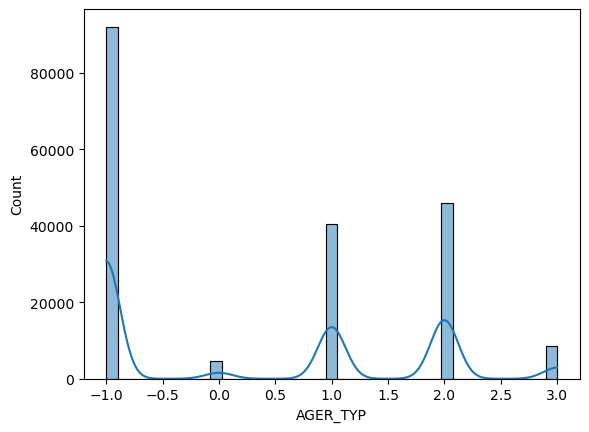

```python
# Plot histogram of age
sns.histplot(data=custormer_clean_df, x="AGER_TYP",  kde=True);
```

# OUTLIERS

```python
def plot_outliers(data_df, column_name):
    """
    Create a box plot to visualize outliers in a specified column of a DataFrame.

    Parameters:
    - data_df (DataFrame): DataFrame containing the data.
    - column_name (str): The name of the column to plot.
    """
    # Create a figure
    fig = plt.figure(figsize=(10, 7))

    # Create a box plot
    plt.boxplot(data_df[column_name].dropna())  # dropna() to handle any missing values
    plt.title(f'Box Plot of {column_name}')
    plt.xlabel(column_name)
    plt.ylabel('Values')

    # Show plot
    plt.show()
```

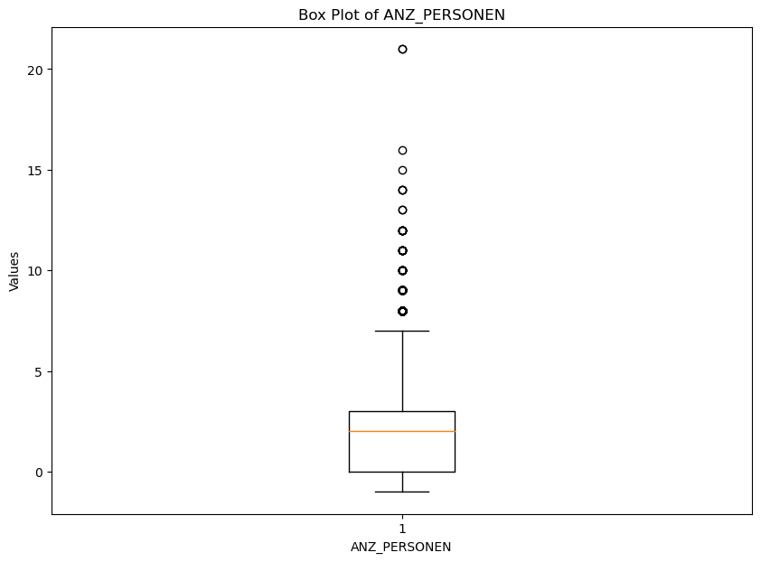

```python
# Plot Number of adult persons in the household
plot_outliers(custormer_clean_df,'ANZ_PERSONEN')
```

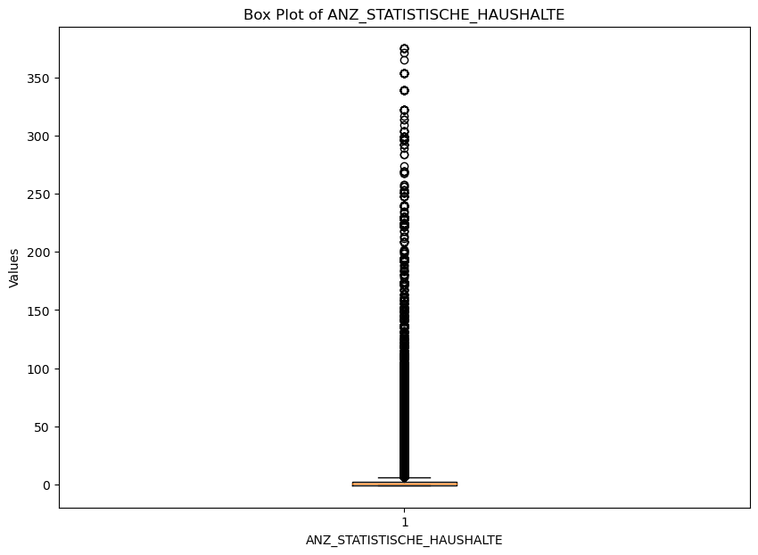

```python
# Plot
plot_outliers(custormer_clean_df,'ANZ_STATISTISCHE_HAUSHALTE')
```

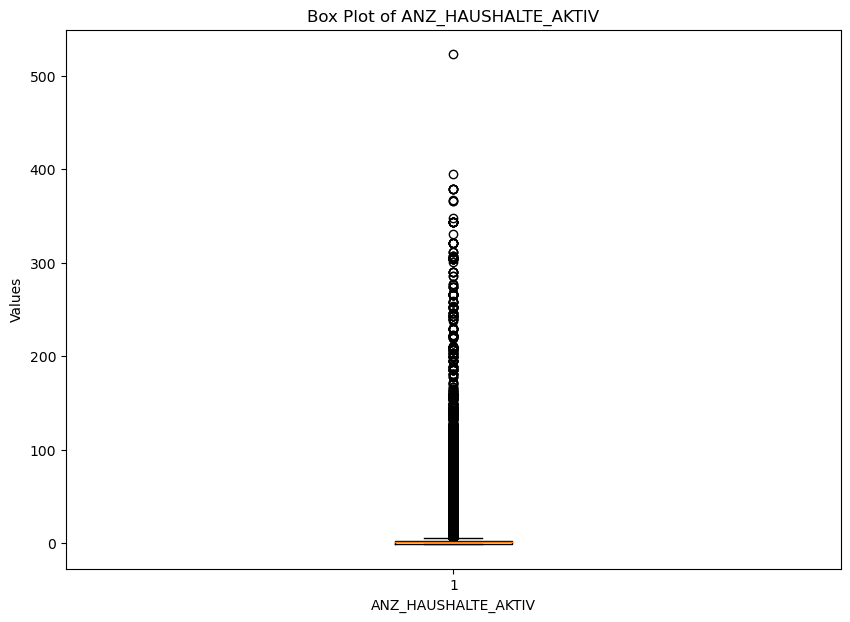

```python
# Plot
plot_outliers(custormer_clean_df,'ANZ_HAUSHALTE_AKTIV')
```

# Performing standard scalling - custormer_data and population data

```python
# store column names
col = custormer_clean_df.columns.tolist()
```

```python
# store column names
col_population = population_data_df.columns.tolist()
```

```python
# standard scalling - importing library.
# standard scaler is chosen because it can handle outliers
from sklearn.preprocessing import StandardScaler
```

```python
# Applying standard scaler on customer data
std_scaler = StandardScaler()
scaled_customer_data = std_scaler.fit_transform(custormer_clean_df) #normalizing the features
```

```python
df_customer_scaled = pd.DataFrame(scaled_customer_data, columns=col)
```

```python
df_customer_scaled.head()
```

|  | AGER_TYP | AKT_DAT_KL | ALTER_HH | ALTERSKATEGORIE_FEIN | ANZ_HAUSHALTE_AKTIV | ANZ_HH_TITEL | ANZ_KINDER | ANZ_PERSONEN | ANZ_STATISTISCHE_HAUSHALTE | ANZ_TITEL | ... | VHN | VK_DHT4A | VK_DISTANZ | VK_ZG11 | W_KEIT_KIND_HH | WOHNDAUER_2008 | WOHNLAGE | ZABEOTYP | ANREDE_KZ | ALTERSKATEGORIE_GROB |
| --- | --- | --- | --- | --- | --- | --- | --- | --- | --- | --- | --- | --- | --- | --- | --- | --- | --- | --- | --- | --- | --- |
| 0 | 1.189729 | -0.037383 | 0.216929 | 0.444525 | -0.191752 | 0.334883 | 0.215579 | 0.284196 | -0.178058 | 0.498156 | ... | 0.844421 | 0.572696 | -0.049949 | -0.047845 | 1.152283 | 0.633999 | 1.640750 | 0.361897 | -0.777125 | 0.864850 |
| 1 | -0.965958 | 3.817933 | 0.348357 | -1.344289 | -0.350676 | -1.168606 | 0.215579 | 0.824147 | -0.338633 | 0.498156 | ... | -1.346222 | 0.863499 | 0.814210 | 0.330236 | -0.947977 | 0.633999 | -1.271192 | 0.361897 | -0.777125 | 0.864850 |
| 2 | -0.965958 | -0.037383 | -0.308780 | -1.181669 | -0.191752 | 0.334883 | 0.215579 | -0.255756 | -0.178058 | 0.498156 | ... | 1.392082 | 2.026711 | 2.830582 | 3.354881 | 1.152283 | 0.633999 | -0.179214 | 0.361897 | 1.286795 | 0.864850 |
| 3 | 0.471167 | -0.037383 | -0.045925 | 0.119286 | -0.271214 | -1.168606 | 0.215579 | -0.795707 | -0.178058 | 0.498156 | ... | 0.296760 | 0.863499 | 0.238104 | -0.047845 | -1.298021 | 0.633999 | 1.640750 | -1.349718 | -0.777125 | 0.864850 |
| 4 | -0.965958 | -0.037383 | 1.531203 | 1.095003 | 0.285018 | 0.334883 | 0.215579 | 1.364099 | 0.303665 | 0.498156 | ... | 1.392082 | -0.008910 | 0.526157 | 0.708316 | -0.247890 | 0.633999 | 0.184779 | -1.349718 | -0.777125 | -0.055717 |

5 rows × 353 columns

```python
# Applying standard scaler on population data
std_scaler = StandardScaler()
scaled_population_data = std_scaler.fit_transform(population_data_df) #normalizing the features
```

```python
df_population_scaled = pd.DataFrame(scaled_population_data, columns=col_population)
```

```python
df_population_scaled.head()
```

|  | LNR | AGER_TYP | AKT_DAT_KL | ALTER_HH | ALTERSKATEGORIE_FEIN | ANZ_HAUSHALTE_AKTIV | ANZ_HH_TITEL | ANZ_KINDER | ANZ_PERSONEN | ANZ_STATISTISCHE_HAUSHALTE | ... | VHN | VK_DHT4A | VK_DISTANZ | VK_ZG11 | W_KEIT_KIND_HH | WOHNDAUER_2008 | WOHNLAGE | ZABEOTYP | ANREDE_KZ | ALTERSKATEGORIE_GROB |
| --- | --- | --- | --- | --- | --- | --- | --- | --- | --- | --- | --- | --- | --- | --- | --- | --- | --- | --- | --- | --- | --- |
| 0 | 1.060904 | -0.535226 | -1.312098 | -1.358510 | -1.304149 | -0.552319 | -2.080548 | -1.836522 | -1.871062 | -0.557461 | ... | -1.849771 | -1.906667 | -1.993751 | -1.934520 | -1.774140 | -2.666609 | -1.879829 | -0.268136 | -1.045182 | -0.727430 |
| 1 | 1.060924 | -0.535226 | 1.325292 | -1.233709 | 1.464505 | 0.244391 | 0.162960 | -0.101996 | 0.371795 | 0.383356 | ... | 1.282605 | 0.772552 | 1.071547 | 1.414530 | -0.138153 | 0.595356 | 0.197450 | 1.210483 | 0.956771 | -1.663103 |
| 2 | 1.060943 | -0.535226 | 1.325292 | 0.887896 | 0.961114 | 0.177999 | 0.162960 | -0.101996 | -0.375824 | 0.021503 | ... | 0.029655 | 1.070243 | 0.560664 | 0.196694 | -0.138153 | 0.595356 | -0.633461 | 1.210483 | 0.956771 | 0.208243 |
| 3 | 1.060947 | 1.967433 | -0.784620 | 0.388695 | 0.457722 | -0.419534 | 0.162960 | -0.101996 | -1.123443 | -0.340350 | ... | -1.223296 | 0.474861 | 0.816106 | 1.718989 | -1.774140 | 0.595356 | 1.443818 | -0.268136 | 0.956771 | 1.143917 |
| 4 | 1.061005 | -0.535226 | -0.784620 | 1.262297 | 0.583570 | -0.286749 | 0.162960 | -0.101996 | 1.867033 | -0.267979 | ... | 0.029655 | -0.715903 | -0.461102 | -0.412225 | -0.547150 | 0.595356 | -0.218006 | 0.471173 | -1.045182 | 0.208243 |

5 rows × 354 columns

# PERFORMING PCA on customer data

```python
# import PCA
from sklearn.decomposition import PCA
```

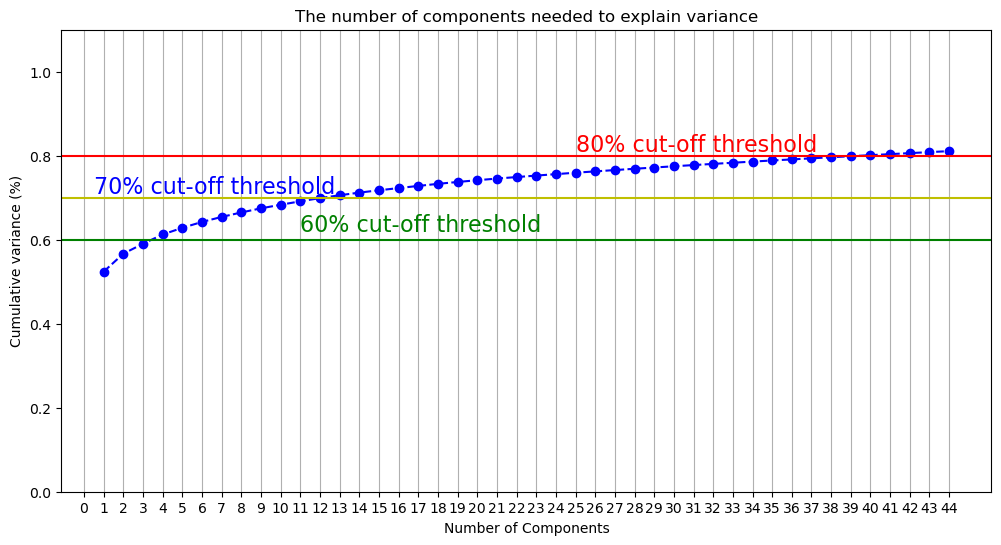

```python
#interating to get the estimate number of components
pca = PCA().fit(scaled_customer_data)

#% matplotlib inline
#import matplotlib.pyplot as plt
plt.rcParams["figure.figsize"] = (12,6)

fig, ax = plt.subplots()
xi = np.arange(1,45, step=1)
y = np.cumsum(pca.explained_variance_ratio_[:44])

plt.ylim(0.0,1.1)
plt.plot(xi, y, marker='o', linestyle='--', color='b')

plt.xlabel('Number of Components')
plt.xticks(np.arange(0, 45, step=1)) #change from 0-based array index to 1-based human-readable label
plt.ylabel('Cumulative variance (%)')
plt.title('The number of components needed to explain variance')

plt.axhline(y=0.80, color='r', linestyle='-')
plt.axhline(y=0.70, color='y', linestyle='-')
plt.axhline(y=0.60, color='g', linestyle='-')

plt.text(25, 0.81, '80% cut-off threshold', color = 'red', fontsize=16)
plt.text(11, 0.62, '60% cut-off threshold', color = 'green', fontsize=16)
plt.text(0.5, 0.71, '70% cut-off threshold', color = 'blue', fontsize=16)

ax.grid(axis='x')
plt.show()
```

```python
#instantiating and applying PCA
pca = PCA(n_components=3)
customer_pca = pca.fit_transform(scaled_customer_data)
print("Original shape was ",scaled_customer_data.shape)
print("New pcs shape is ",customer_pca.shape)
```

```
Original shape was  (191526, 353)
New pcs shape is  (191526, 3)
```

```python
print('Explained variation per principal component: {}'.format(pca.explained_variance_ratio_))
```

```
Explained variation per principal component: [0.52403194 0.04270215 0.02365042]
```

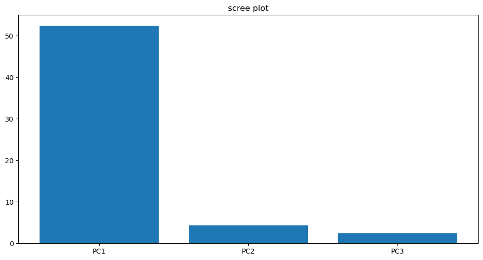

```python
# Display scree plot
per_var = np.round(pca.explained_variance_ratio_*100,decimals=1)

label =['PC' + str(x) for x in range(1, len(per_var) +1)]

plt.bar(x=range(1,len(per_var)+1), height=per_var, tick_label=label)
plt.title('scree plot')
plt.show()
```

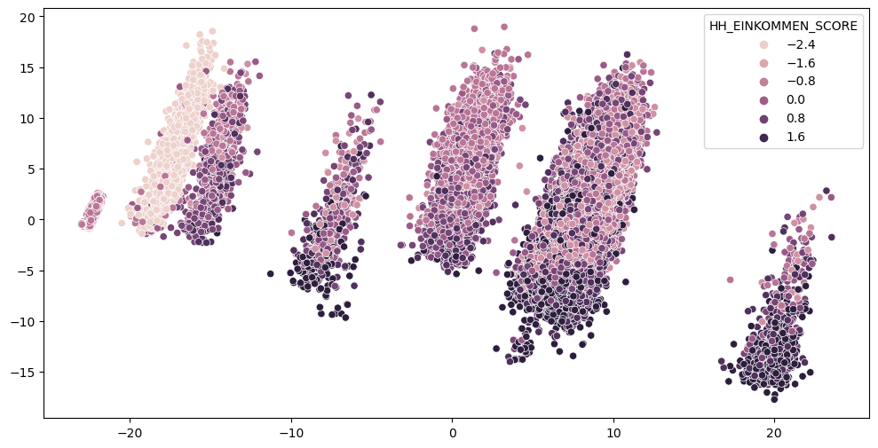

```python
#plotting PCA
plt.figure()
sns.scatterplot(x=customer_pca[:,0], y=customer_pca[:,1], hue=df_customer_scaled['HH_EINKOMMEN_SCORE'])
#scatter = (plt.scatter(x_pca[:,0], x_pca[:,1],colour = 'x_pca') )
plt.show()
```

## Performing PCA on population data

```python
from sklearn.decomposition import PCA
pca = PCA(n_components =7)
population_pca = pca.fit_transform(scaled_population_data)
```

```python
#Display shape
print("Original shape was ",scaled_population_data.shape)
print("New pcs shape is ",population_pca.shape)
```

```
Original shape was  (890848, 354)
New pcs shape is  (890848, 7)
```

```python
print('Explained variation per principal component: {}'.format(pca.explained_variance_ratio_))
```

```
Explained variation per principal component: [0.33263708 0.06793256 0.04902553 0.04040299 0.02616813 0.02067886
 0.01816036]
```

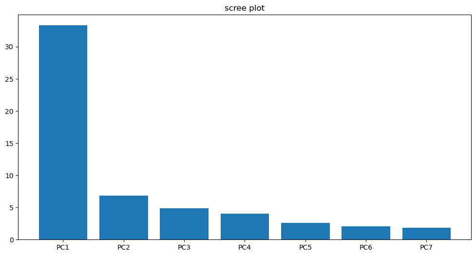

```python
per_var = np.round(pca.explained_variance_ratio_*100,decimals=1)

label =['PC' + str(x) for x in range(1, len(per_var) +1)]

plt.bar(x=range(1,len(per_var)+1), height=per_var, tick_label=label)
plt.title('scree plot')
plt.show()
```

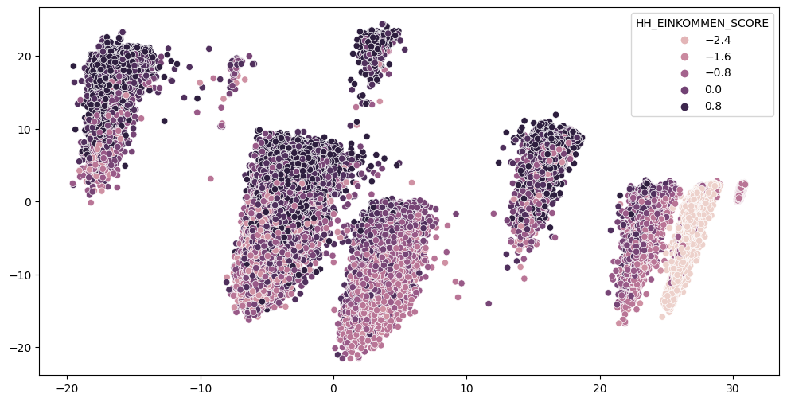

```python
#plotting PCA
plt.figure()
sns.scatterplot(x=population_pca[:,0], y=population_pca[:,1],hue=df_population_scaled['HH_EINKOMMEN_SCORE'])
#scatter = (plt.scatter(x_pca[:,0], x_pca[:,1],colour = 'x_pca') )
plt.show()
```

## Part 1: Customer Segmentation Report

The main bulk of your analysis will come in this part of the project. Here, you should use unsupervised learning techniques to describe the relationship between the demographics of the company's existing customers and the general population of Germany. By the end of this part, you should be able to describe parts of the general population that are more likely to be part of the mail-order company's main customer base, and which parts of the general population are less so.

## KMeans clustering

```python
# import libraries
import pandas as pd
import numpy as np
import matplotlib.pyplot as plt
import seaborn as sns

from sklearn.cluster import KMeans
```

```python
# create a loop to check number of features(elbow method)
wscc = []
for i in range(1,31):
    kmeans = KMeans(n_clusters=i, init="k-means++")
    kmeans.fit(population_scaled_data)
    wscc.append(kmeans.inertia_)
```

[output not shown]

[output cut: 20 more lines]

```python
import matplotlib.pyplot as plt
```

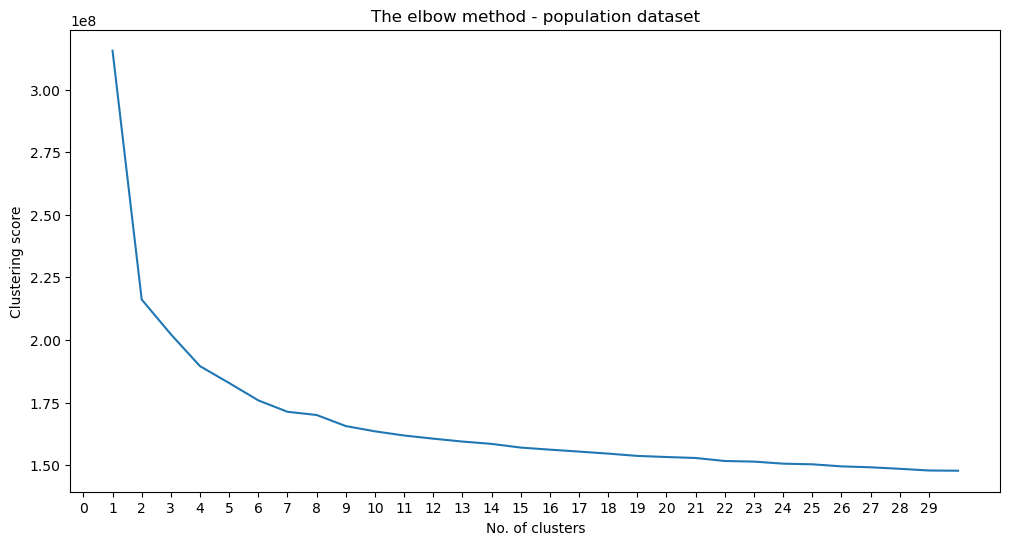

```python
# plot scree plot to show "ideal" no. of clusters required(n_cluster) - population data

#plt.figure(figsize(10,6))
plt.figure()
plt.plot(range(1,31),wscc)
plt.title("The elbow method - population dataset")
plt.xlabel("No. of clusters")
plt.ylabel("Clustering score")
plt.xticks(np.arange(0, 30, step=1))
plt.show()
```

```python
# create a loop to check number of features(elbow method)
number_of_clusters = []
for i in range(1,25):
    kmeans_c = KMeans(n_clusters=i, init="k-means++")
    kmeans_c.fit(scaled_customer_data)
    number_of_clusters.append(kmeans_c.inertia_)
```

[output not shown]

[output cut: 16 more lines]

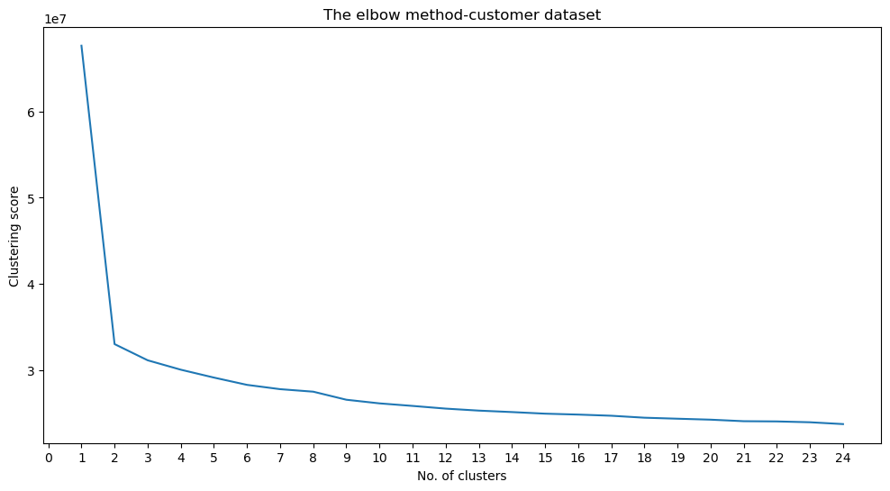

```python
# plot scree plot to show "ideal" no. of clusters required(n_cluster) - customer data

plt.figure()
plt.plot(range(1,25),number_of_clusters)
plt.title("The elbow method-customer dataset")
plt.xlabel("No. of clusters")
plt.ylabel("Clustering score")
plt.xticks(np.arange(0, 25, step=1))
plt.show()
```

```python
# Fit the model and predict customer data
kmeans_c = KMeans(n_clusters=3)
kmeans_c.fit(scaled_data)
pred_c = kmeans_c.predict(scaled_customer_data)
pred_c
```

```
array([2, 1, 2, ..., 2, 0, 0])
```

```python
# adding cluster column to main scaled customer data
df_scaled["Cluster"]=pd.DataFrame(pred_c,columns=['cluster'])
df_scaled.head()
```

|  | AGER_TYP | AKT_DAT_KL | ALTER_HH | ALTERSKATEGORIE_FEIN | ANZ_HAUSHALTE_AKTIV | ANZ_HH_TITEL | ANZ_KINDER | ANZ_PERSONEN | ANZ_STATISTISCHE_HAUSHALTE | ANZ_TITEL | ... | VK_DHT4A | VK_DISTANZ | VK_ZG11 | W_KEIT_KIND_HH | WOHNDAUER_2008 | WOHNLAGE | ZABEOTYP | ANREDE_KZ | ALTERSKATEGORIE_GROB | Cluster |
| --- | --- | --- | --- | --- | --- | --- | --- | --- | --- | --- | --- | --- | --- | --- | --- | --- | --- | --- | --- | --- | --- |
| 0 | 1.189681 | -0.038281 | 0.217030 | 0.444564 | -0.191696 | 0.335039 | 0.215397 | 0.284430 | -0.177976 | 0.497891 | ... | 0.572222 | -0.050342 | -0.048217 | 1.152321 | 0.63384 | 1.640934 | 0.362174 | -0.776965 | 0.864527 | 2 |
| 1 | -0.966005 | 3.812716 | 0.348474 | -1.344347 | -0.350667 | -1.168624 | 0.215397 | 0.824481 | -0.338600 | 0.497891 | ... | 0.862984 | 0.813674 | 0.329767 | -0.947784 | 0.63384 | -1.271568 | 0.362174 | -0.776965 | 0.864527 | 1 |
| 2 | -0.966005 | -0.038281 | -0.308748 | -1.181718 | -0.191696 | 0.335039 | 0.215397 | -0.255621 | -0.177976 | 0.497891 | ... | 2.026032 | 2.829713 | 3.353644 | 1.152321 | 0.63384 | -0.179380 | 0.362174 | 1.287059 | 0.864527 | 2 |
| 3 | 0.471119 | -0.038281 | -0.045859 | 0.119308 | -0.271181 | -1.168624 | 0.215397 | -0.795672 | -0.177976 | 0.497891 | ... | 0.862984 | 0.237663 | -0.048217 | -1.297802 | 0.63384 | 1.640934 | -1.349447 | -0.776965 | 0.864527 | 2 |
| 4 | -0.966005 | -0.038281 | 1.531475 | 1.095077 | 0.285218 | 0.335039 | 0.215397 | 1.364532 | 0.303897 | 0.497891 | ... | -0.009302 | 0.525669 | 0.707752 | -0.247749 | 0.63384 | 0.184683 | -1.349447 | -0.776965 | -0.056071 | 0 |

5 rows × 354 columns

[figure not shown]

```python
# plot
sns.scatterplot(x=df_scaled['ANREDE_KZ'],y=df_scaled['KKK'],hue=df_scaled['Cluster'])
plt.title("Customer cluster")
plt.xlabel("Gender")
plt.ylabel("purchasing power")
plt.show()
```

```python
# adding cluster column to main scaled customer data
custormer_clean_df["Cluster"]=pd.DataFrame(pred_c,columns=['cluster'])
custormer_clean_df
```

|  | AGER_TYP | AKT_DAT_KL | ALTER_HH | ALTERSKATEGORIE_FEIN | ANZ_HAUSHALTE_AKTIV | ANZ_HH_TITEL | ANZ_KINDER | ANZ_PERSONEN | ANZ_STATISTISCHE_HAUSHALTE | ANZ_TITEL | ... | VK_DHT4A | VK_DISTANZ | VK_ZG11 | W_KEIT_KIND_HH | WOHNDAUER_2008 | WOHNLAGE | ZABEOTYP | ANREDE_KZ | ALTERSKATEGORIE_GROB | Cluster |
| --- | --- | --- | --- | --- | --- | --- | --- | --- | --- | --- | --- | --- | --- | --- | --- | --- | --- | --- | --- | --- | --- |
| 0 | 2 | 1.0 | 10.0 | 10.0 | 1.0 | 0.0 | 0.0 | 2.0 | 1.0 | 0.0 | ... | 5.0 | 3.0 | 2.0 | 6.0 | 9.0 | 7.0 | 3 | 1 | 4 | 2 |
| 1 | -1 | 9.0 | 11.0 | -1.0 | -1.0 | -1.0 | 0.0 | 3.0 | -1.0 | 0.0 | ... | 6.0 | 6.0 | 3.0 | 0.0 | 9.0 | -1.0 | 3 | 1 | 4 | 1 |
| 2 | -1 | 1.0 | 6.0 | 0.0 | 1.0 | 0.0 | 0.0 | 1.0 | 1.0 | 0.0 | ... | 10.0 | 13.0 | 11.0 | 6.0 | 9.0 | 2.0 | 3 | 2 | 4 | 2 |
| 3 | 1 | 1.0 | 8.0 | 8.0 | 0.0 | -1.0 | 0.0 | 0.0 | 1.0 | 0.0 | ... | 6.0 | 4.0 | 2.0 | -1.0 | 9.0 | 7.0 | 1 | 1 | 4 | 2 |
| 4 | -1 | 1.0 | 20.0 | 14.0 | 7.0 | 0.0 | 0.0 | 4.0 | 7.0 | 0.0 | ... | 3.0 | 5.0 | 4.0 | 2.0 | 9.0 | 3.0 | 1 | 1 | 3 | 0 |
| ... | ... | ... | ... | ... | ... | ... | ... | ... | ... | ... | ... | ... | ... | ... | ... | ... | ... | ... | ... | ... | ... |
| 191647 | 1 | 1.0 | 9.0 | 9.0 | 1.0 | 0.0 | 0.0 | 1.0 | 1.0 | 0.0 | ... | 8.0 | 8.0 | 5.0 | 6.0 | 9.0 | 1.0 | 3 | 1 | 3 | 2 |
| 191648 | -1 | 2.0 | 0.0 | 0.0 | 0.0 | -1.0 | 0.0 | 0.0 | 1.0 | 0.0 | ... | 10.0 | 7.0 | 4.0 | -1.0 | 9.0 | 3.0 | 3 | 2 | 4 | 2 |
| 191649 | 2 | 1.0 | 15.0 | 10.0 | 1.0 | 0.0 | 0.0 | 3.0 | 1.0 | 0.0 | ... | 8.0 | 8.0 | 5.0 | 3.0 | 9.0 | 3.0 | 3 | 1 | 4 | 2 |
| 191650 | 3 | 1.0 | 13.0 | 13.0 | 4.0 | 0.0 | 0.0 | 4.0 | 3.0 | 0.0 | ... | 1.0 | 1.0 | 1.0 | 4.0 | 9.0 | 2.0 | 3 | 2 | 3 | 0 |
| 191651 | 3 | 1.0 | 0.0 | 9.0 | 1.0 | 0.0 | 0.0 | 3.0 | 1.0 | 0.0 | ... | 1.0 | 1.0 | 1.0 | 3.0 | 9.0 | 7.0 | 1 | 1 | 2 | 0 |

191652 rows × 354 columns

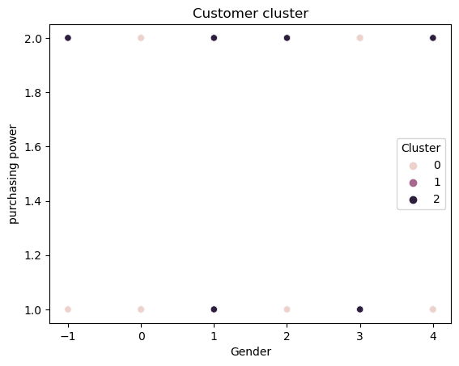

```python
# plot
sns.scatterplot(y=custormer_clean_df['ANREDE_KZ'],x=custormer_clean_df['KKK'],hue=custormer_clean_df['Cluster'])
plt.title("Customer cluster")
plt.xlabel("Gender")
plt.ylabel("purchasing power")
plt.show()
```

```python
# Fit the model and predict population data
kmeans_p = KMeans(n_clusters = 7)
kmeans_p.fit(population_scaled_data)
pred_p = kmeans_p.predict(population_scaled_data)
pred_p
```

```
array([4, 1, 1, ..., 2, 1, 6])
```

```python
# adding cluster column to main scaled customer data
population_data_df["Cluster"]=pd.DataFrame(pred_p,columns=['cluster'])
population_data_df
```

|  | LNR | AGER_TYP | AKT_DAT_KL | ALTER_HH | ALTERSKATEGORIE_FEIN | ANZ_HAUSHALTE_AKTIV | ANZ_HH_TITEL | ANZ_KINDER | ANZ_PERSONEN | ANZ_STATISTISCHE_HAUSHALTE | ... | VK_DHT4A | VK_DISTANZ | VK_ZG11 | W_KEIT_KIND_HH | WOHNDAUER_2008 | WOHNLAGE | ZABEOTYP | ANREDE_KZ | ALTERSKATEGORIE_GROB | Cluster |
| --- | --- | --- | --- | --- | --- | --- | --- | --- | --- | --- | --- | --- | --- | --- | --- | --- | --- | --- | --- | --- | --- |
| 0 | 910215 | -1 | -1.0 | -1.0 | -1.0 | -1.0 | -1.0 | -1.0 | -1.0 | -1.0 | ... | -1.0 | -1.0 | -1.0 | -1.0 | -1.0 | -1.0 | 3 | 1 | 2 | 4 |
| 1 | 910220 | -1 | 9.0 | 0.0 | 21.0 | 11.0 | 0.0 | 0.0 | 2.0 | 12.0 | ... | 8.0 | 11.0 | 10.0 | 3.0 | 9.0 | 4.0 | 5 | 2 | 1 | 1 |
| 2 | 910225 | -1 | 9.0 | 17.0 | 17.0 | 10.0 | 0.0 | 0.0 | 1.0 | 7.0 | ... | 9.0 | 9.0 | 6.0 | 3.0 | 9.0 | 2.0 | 5 | 2 | 3 | 1 |
| 3 | 910226 | 2 | 1.0 | 13.0 | 13.0 | 1.0 | 0.0 | 0.0 | 0.0 | 2.0 | ... | 7.0 | 10.0 | 11.0 | -1.0 | 9.0 | 7.0 | 3 | 2 | 4 | 6 |
| 4 | 910241 | -1 | 1.0 | 20.0 | 14.0 | 3.0 | 0.0 | 0.0 | 4.0 | 3.0 | ... | 3.0 | 5.0 | 4.0 | 2.0 | 9.0 | 3.0 | 4 | 1 | 3 | 2 |
| ... | ... | ... | ... | ... | ... | ... | ... | ... | ... | ... | ... | ... | ... | ... | ... | ... | ... | ... | ... | ... | ... |
| 891216 | 825761 | -1 | 5.0 | 17.0 | 17.0 | 15.0 | 0.0 | 0.0 | 1.0 | 11.0 | ... | 4.0 | 7.0 | 8.0 | 3.0 | 4.0 | 3.0 | 4 | 2 | 3 | 2 |
| 891217 | 825771 | -1 | 9.0 | 16.0 | 16.0 | 11.0 | 0.0 | 0.0 | 1.0 | 11.0 | ... | 6.0 | 9.0 | 6.0 | 6.0 | 9.0 | 5.0 | 6 | 1 | 2 | 1 |
| 891218 | 825772 | -1 | 1.0 | 17.0 | 17.0 | 3.0 | 0.0 | 0.0 | 0.0 | 3.0 | ... | 7.0 | 10.0 | 8.0 | -1.0 | 5.0 | 7.0 | 4 | 2 | 2 | 2 |
| 891219 | 825776 | -1 | 9.0 | 0.0 | 20.0 | 7.0 | 0.0 | 1.0 | 1.0 | 5.0 | ... | 9.0 | 8.0 | 5.0 | 1.0 | 9.0 | 5.0 | 5 | 1 | 1 | 1 |
| 891220 | 825787 | -1 | 1.0 | 0.0 | -1.0 | 10.0 | 0.0 | 0.0 | 1.0 | 5.0 | ... | 8.0 | 10.0 | 7.0 | 6.0 | 3.0 | 4.0 | 3 | 1 | 4 | 6 |

891221 rows × 355 columns

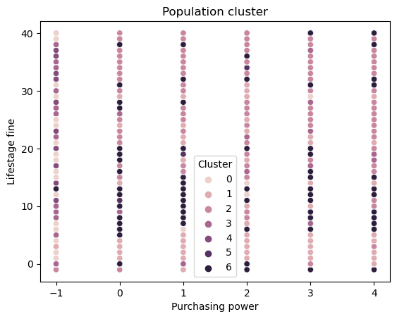

```python
# plot
sns.scatterplot(y=population_data_df['LP_LEBENSPHASE_FEIN'],x=population_data_df['KKK'],hue=population_data_df['Cluster'])
plt.title("Population cluster")
plt.xlabel("Purchasing power")
plt.ylabel("Lifestage fine")
plt.show()
```

## Part 2: Supervised Learning Model

Now that you've found which parts of the population are more likely to be customers of the mail-order company, it's time to build a prediction model. Each of the rows in the "MAILOUT" data files represents an individual that was targeted for a mailout campaign. Ideally, we should be able to use the demographic information from each individual to decide whether or not it will be worth it to include that person in the campaign.

The "MAILOUT" data has been split into two approximately equal parts, each with almost 43 000 data rows. In this part, you can verify your model with the "TRAIN" partition, which includes a column, "RESPONSE", that states whether or not a person became a customer of the company following the campaign. In the next part, you'll need to create predictions on the "TEST" partition, where the "RESPONSE" column has been withheld.

```python
mailout_train = pd.read_csv('mailout_train.csv', sep=',')
```

```python
mailout_train.head()
```

|  | LNR | AGER_TYP | AKT_DAT_KL | ALTER_HH | ALTER_KIND1 | ALTER_KIND2 | ALTER_KIND3 | ALTER_KIND4 | ALTERSKATEGORIE_FEIN | ANZ_HAUSHALTE_AKTIV | ... | VK_DHT4A | VK_DISTANZ | VK_ZG11 | W_KEIT_KIND_HH | WOHNDAUER_2008 | WOHNLAGE | ZABEOTYP | RESPONSE | ANREDE_KZ | ALTERSKATEGORIE_GROB |
| --- | --- | --- | --- | --- | --- | --- | --- | --- | --- | --- | --- | --- | --- | --- | --- | --- | --- | --- | --- | --- | --- |
| 0 | 1763 | 2 | 1.0 | 8.0 | NaN | NaN | NaN | NaN | 8.0 | 15.0 | ... | 5.0 | 2.0 | 1.0 | 6.0 | 9.0 | 3.0 | 3 | 0 | 2 | 4 |
| 1 | 1771 | 1 | 4.0 | 13.0 | NaN | NaN | NaN | NaN | 13.0 | 1.0 | ... | 1.0 | 2.0 | 1.0 | 4.0 | 9.0 | 7.0 | 1 | 0 | 2 | 3 |
| 2 | 1776 | 1 | 1.0 | 9.0 | NaN | NaN | NaN | NaN | 7.0 | 0.0 | ... | 6.0 | 4.0 | 2.0 | NaN | 9.0 | 2.0 | 3 | 0 | 1 | 4 |
| 3 | 1460 | 2 | 1.0 | 6.0 | NaN | NaN | NaN | NaN | 6.0 | 4.0 | ... | 8.0 | 11.0 | 11.0 | 6.0 | 9.0 | 1.0 | 3 | 0 | 2 | 4 |
| 4 | 1783 | 2 | 1.0 | 9.0 | NaN | NaN | NaN | NaN | 9.0 | 53.0 | ... | 2.0 | 2.0 | 1.0 | 6.0 | 9.0 | 3.0 | 3 | 0 | 1 | 3 |

5 rows × 367 columns

```python
mailout_train.shape
```

```
(42962, 367)
```

```python
mailout_train_clean = clean_dataframe(mailout_train)
```

```python
mailout_train_clean.shape
```

```
(42962, 355)
```

```python
mailout_train_clean.info()
```

```
<class 'pandas.core.frame.DataFrame'>
RangeIndex: 42962 entries, 0 to 42961
Columns: 355 entries, LNR to ALTERSKATEGORIE_GROB
dtypes: float64(261), int64(94)
memory usage: 116.4 MB
```

```python
mailout_train_clean['RESPONSE'].value_counts()
```

```
0    42430
1      532
Name: RESPONSE, dtype: int64
```

```python
mailout_test = pd.read_csv('mailout_test.csv', sep=',')
```

```python
mailout_test.tail()
```

|  | LNR | AGER_TYP | AKT_DAT_KL | ALTER_HH | ALTER_KIND1 | ALTER_KIND2 | ALTER_KIND3 | ALTER_KIND4 | ALTERSKATEGORIE_FEIN | ANZ_HAUSHALTE_AKTIV | ... | VHN | VK_DHT4A | VK_DISTANZ | VK_ZG11 | W_KEIT_KIND_HH | WOHNDAUER_2008 | WOHNLAGE | ZABEOTYP | ANREDE_KZ | ALTERSKATEGORIE_GROB |
| --- | --- | --- | --- | --- | --- | --- | --- | --- | --- | --- | --- | --- | --- | --- | --- | --- | --- | --- | --- | --- | --- |
| 42828 | 67615 | -1 | NaN | NaN | NaN | NaN | NaN | NaN | NaN | NaN | ... | NaN | NaN | NaN | NaN | NaN | NaN | NaN | 3 | 2 | 1 |
| 42829 | 67938 | 0 | 1.0 | 10.0 | NaN | NaN | NaN | NaN | 10.0 | 2.0 | ... | 4.0 | 10.0 | 9.0 | 6.0 | 6.0 | 9.0 | 3.0 | 3 | 1 | 4 |
| 42830 | 67942 | -1 | 1.0 | 16.0 | 14.0 | 17.0 | NaN | NaN | 15.0 | 1.0 | ... | 2.0 | 1.0 | 1.0 | 1.0 | 1.0 | 9.0 | 3.0 | 2 | 1 | 3 |
| 42831 | 67949 | -1 | 1.0 | 0.0 | NaN | NaN | NaN | NaN | 0.0 | 1.0 | ... | 1.0 | 4.0 | 4.0 | 2.0 | 6.0 | 9.0 | 3.0 | 3 | 2 | 3 |
| 42832 | 68898 | -1 | 1.0 | 14.0 | NaN | NaN | NaN | NaN | 14.0 | 1.0 | ... | 2.0 | 1.0 | 1.0 | 1.0 | 4.0 | 9.0 | 4.0 | 3 | 2 | 3 |

5 rows × 366 columns

```python
mailout_test_clean = clean_dataframe(mailout_test)
```

```python
mailout_test_clean.head()
```

|  | LNR | AGER_TYP | AKT_DAT_KL | ALTER_HH | ALTERSKATEGORIE_FEIN | ANZ_HAUSHALTE_AKTIV | ANZ_HH_TITEL | ANZ_KINDER | ANZ_PERSONEN | ANZ_STATISTISCHE_HAUSHALTE | ... | VHN | VK_DHT4A | VK_DISTANZ | VK_ZG11 | W_KEIT_KIND_HH | WOHNDAUER_2008 | WOHNLAGE | ZABEOTYP | ANREDE_KZ | ALTERSKATEGORIE_GROB |
| --- | --- | --- | --- | --- | --- | --- | --- | --- | --- | --- | --- | --- | --- | --- | --- | --- | --- | --- | --- | --- | --- |
| 0 | 1754 | 2 | 1.0 | 7.0 | 6.0 | 2.0 | 0.0 | 0.0 | 2.0 | 2.0 | ... | 4.0 | 5.0 | 6.0 | 3.0 | 6.0 | 9.0 | 3.0 | 3 | 1 | 4 |
| 1 | 1770 | -1 | 1.0 | 0.0 | 0.0 | 20.0 | 0.0 | 0.0 | 1.0 | 21.0 | ... | 1.0 | 5.0 | 2.0 | 1.0 | 6.0 | 9.0 | 5.0 | 3 | 1 | 4 |
| 2 | 1465 | 2 | 9.0 | 16.0 | 11.0 | 2.0 | 0.0 | 0.0 | 4.0 | 2.0 | ... | 3.0 | 9.0 | 6.0 | 3.0 | 2.0 | 9.0 | 4.0 | 3 | 2 | 4 |
| 3 | 1470 | -1 | 7.0 | 0.0 | 0.0 | 1.0 | 0.0 | 0.0 | 0.0 | 1.0 | ... | 2.0 | 6.0 | 6.0 | 3.0 | -1.0 | 9.0 | 2.0 | 3 | 2 | 4 |
| 4 | 1478 | 1 | 1.0 | 21.0 | 13.0 | 1.0 | 0.0 | 0.0 | 4.0 | 1.0 | ... | 1.0 | 2.0 | 4.0 | 3.0 | 3.0 | 9.0 | 7.0 | 4 | 2 | 4 |

5 rows × 354 columns

## Both training and test dataframe were cleaned using the clean dataframe function

```python
# Split data into X and y
X = mailout_train_clean.drop('RESPONSE', axis=1)
y = mailout_train_clean['RESPONSE']
```

## Applying standard scaler to X

```python
column_X = X.columns.tolist()
```

```python
column_test = mailout_test_clean.columns.tolist()
```

```python
from sklearn.preprocessing import StandardScaler
```

```python
std_scaler = StandardScaler()
scaled_X = std_scaler.fit_transform(X)
```

```python
df_scaled_X = pd.DataFrame(scaled_X,columns=column_X)
```

```python
scaled_mailout_test_clean = std_scaler.fit_transform(mailout_test_clean)
```

```python
df_scaled_mailout_test_clean = pd.DataFrame(scaled_mailout_test_clean,columns=column_test)
```

```python
X = df_scaled_X
```

### Three different models will be tried namely:-

```python
#import libraries for modelling

from sklearn.neighbors import KNeighborsClassifier
from sklearn.ensemble import RandomForestClassifier
from sklearn.metrics import accuracy_score, confusion_matrix, precision_score, recall_score, ConfusionMatrixDisplay
from sklearn.model_selection import RandomizedSearchCV
from sklearn.linear_model import LogisticRegression
from sklearn.linear_model import SGDClassifier
```

```python
from sklearn.model_selection import train_test_split
X_train, X_test, y_train, y_test = train_test_split(X, y, random_state=0, test_size = 0.2)
```

```python
# create dictionary for models
models = {"SGD":SGDClassifier(),
         "KNN":KNeighborsClassifier(),
         "Random Forest":RandomForestClassifier()}
#Create a function to fit and score models
def fit_and_score(models,X_train,X_test,y_train,y_test):
    '''
    Fits and evaluate givel ML models

    Parameters:
    models : a dictionary of different classification ML models
    X_tarin : trining data - no labels
    X_test : testing data - no labels
    y_train : training labels
    y_test : test labels
    '''
    model_scores = {}
    # loop through models
    for name, model in models.items():
        model.fit(X_train,y_train) #fit the model
        model_scores[name] = model.score(X_test,y_test) # evaluate model and append its score to model scores

    return model_scores
```

```python
model_scores = fit_and_score(models=models,
                            X_train=X_train,
                            X_test=X_test,
                            y_train=y_train,
                            y_test=y_test)
```

```python
model_scores
```

```
{'SGD': 0.9838240428255557,
 'KNN': 0.9878971255673222,
 'Random Forest': 0.9870825090189689}
```

```python
# From above it seems the KNN is the better model,
```

```python
model =KNeighborsClassifier()
model.fit(X_train,y_train)
```

```
KNeighborsClassifier()
```

```python
from sklearn.model_selection import cross_val_score

# Cross-validation scores
cv_scores = cross_val_score(model, X_train, y_train, cv=5, scoring='accuracy')
print(f'Cross-validated sccuracy: {cv_scores.mean()}')
```

```
Cross-validated sccuracy: 0.9874887294956618
```

```python
from sklearn.model_selection import cross_val_score

# Cross-validation scores
cv_scores = cross_val_score(model, X_train, y_train, cv=5, scoring='recall')
print(f'Cross-validated precision: {cv_scores.mean()}')
```

```
Cross-validated precision: 0.0
```

```python
# Generate predictions on the test data
y_test_predictions = model.predict(df_scaled_mailout_test_clean)
```

```python
y_test_predictions
```

```
array([0, 0, 0, ..., 0, 0, 0], dtype=int64)
```

```python
# Convert predictions to DataFrame
test_predictions_df = pd.DataFrame({
    'LNR':df_scaled_mailout_test_clean ['LNR'],
    'PREDICTION': y_test_predictions})
```

```python
test_predictions_df
```

|  | LNR | PREDICTION |
| --- | --- | --- |
| 0 | -1.665871 | 0 |
| 1 | -1.665225 | 0 |
| 2 | -1.677546 | 0 |
| 3 | -1.677344 | 0 |
| 4 | -1.677021 | 0 |
| ... | ... | ... |
| 42828 | 0.994608 | 0 |
| 42829 | 1.007656 | 0 |
| 42830 | 1.007817 | 0 |
| 42831 | 1.008100 | 0 |
| 42832 | 1.046435 | 0 |

42833 rows × 2 columns